# WGS Analysis of BO and normal gastric organoids and matched tissues

2025-05-15

The aim of this script is to summarise the WGS data of BO and normal gastric organoids and matched tissues. In this case, we can begin to investigate driver events during early BO development, and perhaps differences across gastric regions and the gastro-oesophageal junction (GOJ).

```r
library(readxl) # to load in excel files
library(tidyverse) # table manipulation
```

```r
library(biomaRt) # Ensembl access
library(ggplot2) # plotting
library(ggpubr) # additional plotting
library(scarHRD) # HRD score calculation
library(vcfR) # read vcf files
library(deconstructSigs) # signature fitting
library(BSgenome.Hsapiens.UCSC.hg19) # reference genome for trinucleotide context determination
library(lsa) # for cosine similarity
library(ComplexHeatmap) # for oncoplot
library(circlize) # for color Ramp
library(ggVennDiagram) # Venn Diagrams
library(tidytext) # facetted barplot organising
library(rstatix) # for plotting adjusted p-values
```

# 1 Data Preprocessing

As a preliminary step, since we will only be analysing OAC driver genes, we can load this list in.

```r
gene_drivers.file <- read_excel('Results/41588_2018_331_MOESM3_ESM.xlsx',
                                sheet = 'ST9 All Drivers dnds ratios',
                                skip = 2)
gene_drivers <- gene_drivers.file$gene_name
```

We will also organoids our respective metadata in order to ensure that indices are correct, and samples from the same patient at different stages can be separated

```r
# Note that this metadata will be used throughout the analysis, and so can be matched and subsetted

meta <- read_excel('Data/WGS for organoid paper_to Daniel and Ginny.xlsx', skip=3)
meta$index_corrected <- meta$Index

## Index corrections

# For those with SLX-18947: replace 'H' with 'i' and 'SLX-18947' with 'SLX-18949'
meta$index_corrected[grepl(pattern = 'SLX-18947', meta$Index)] <-
  sapply(meta$Index[grepl(pattern = 'SLX-18947', meta$Index)], function(x)
    paste0('SLX-18949.i',substr(strsplit(x,split='H')[[1]][2],1,3),'_i',strsplit(x,split='H')[[1]][3]))
# For those with SLX-21369: paste 'SLX-21369_SLX-26253.UDP' before the UDP number
meta$index_corrected[grepl(pattern = 'SLX-21369', meta$Index)] <-
  sapply(meta$Index[grepl(pattern = 'SLX-21369', meta$Index)], function(x)
    paste0('SLX-21369_SLX-26253.UDP',strsplit(x,split='UDP')[[1]][3]))
# Finally, replace '-i' with '_i'
meta$index_corrected <- as.character(
  sapply(meta$index_corrected, function(x) str_replace(x,pattern='-i', replacement='_i')))

## Remove OAC samples (these are present in the other oncoplot)
meta <- meta %>% dplyr::filter(`Tissue/Organoid Grade` != 'EAC')

## Fix 'OC/AH/' to 'CAM'
meta$`Patient ID` <- sapply(meta$`Patient ID`, function(x) str_replace(x,'OC/AH/','CAM'))

## Replace 'Normal' with 'Normal (Healthy)' (if Highest grade == 'Normal donor') and 'Normal (Patient)' otherwise
meta$`Tissue/Organoid Grade`[meta$`Highest grade` == 'Normal donor'] <- 'Normal (Healthy)'
meta$`Tissue/Organoid Grade`[meta$`Tissue/Organoid Grade` == 'Normal'] <- 'Normal (Patient)'

## Fix 'Dysplasia (wait for WGS)' to 'Dysplasia' and add Organoid grade to patient ID
meta$`Tissue/Organoid Grade`[meta$`Tissue/Organoid Grade` == 'Dysplasia (wait for WGS)'] <- 'Dysplasia'
meta$`Tissue/Organoid Grade` <- sapply(meta$`Tissue/Organoid Grade`, function(x) str_replace(x,'BE No dysplasia','BO No dysplasia'))
meta$`Patient ID` <- apply(meta, 1, function(x) paste(x['Patient ID'],x['Tissue/Organoid Grade'],sep='_'))

# Since we have two organoid/tissue pairs for dysplastic AHM2165, we can rename those labelled as 'BE36'
meta$`Patient ID`[grepl(pattern = 'AHM2165.BE36', meta$`Sample ID`)] <- 'AHM2165_Dysplasia_2'

# Additionally, we need to differentiate the gastric organoids from normal donors. We can add the site. This also applies for the AHM0593 normal gastric organoids
meta$`Patient ID`[meta$`Tissue specific clinic info` == 'Normal donor'] <- apply(
  meta[meta$`Tissue specific clinic info` == 'Normal donor',], 1, function(x)
    paste(x['Patient ID'],x['Type/site'],sep='_')
)
meta$`Patient ID`[meta$`Patient ID` == 'AHM0593_Normal (Patient)' & meta$`Organoid or Tissue` == 'Organoids'] <- apply(
  meta[meta$`Patient ID` == 'AHM0593_Normal (Patient)' & meta$`Organoid or Tissue` == 'Organoids',], 1, function(x)
    paste(x['Patient ID'],x['Type/site'],sep='_')
)

# Fix highest grade
meta$HighestGrade <- sapply(meta$`Highest grade`, function(x) strsplit(x,split='[(]')[[1]][1])
meta$HighestGrade[meta$HighestGrade == 'BE No dysplasia '] <- 'BE No dysplasia'
meta$HighestGrade[meta$HighestGrade == 'EAC '] <- 'EAC'
meta$HighestGrade[meta$HighestGrade == 'Gastric cancer '] <- 'Gastric cancer'

# Fix Englishisms
meta$`Tissue/Organoid Grade`[meta$`Tissue/Organoid Grade` == 'BE No dysplasia'] <- 'BO No dysplasia'
meta$`Tissue/Organoid Grade`[meta$`Tissue/Organoid Grade` == 'EAC'] <- 'OAC'

meta$HighestGrade[meta$HighestGrade == 'BE No dysplasia'] <- 'BO No dysplasia'
meta$HighestGrade[meta$HighestGrade == 'EAC'] <- 'OAC'
```

## 1.1 Sort mutation data

The set of data to be included in the oncoplot is stored in the directories ‘Data/ascat’ and ‘Data/strelka’. Additional data for other aspects of the project will be added here too.

```r
# List respective VEP files
vep.files <- list.files(path = 'Data/strelka', pattern = '.pass.coding.supplemented.vep$',
                        recursive = TRUE, full.names = TRUE)

# Extract VEP files matched to samples included in the metadata (this is all correct)
vep.files_sequenceID <- sapply(vep.files, function(x)
  strsplit(strsplit(x,split='/')[[1]][3],split='_vs_')[[1]][1])
vep.files_include <- vep.files_sequenceID %in% meta$index_corrected

# Collate all VEP files into a single data frame, additionally highlighting the gene, mutationID, and mutation type, noting that each file has either 16 or 18 columns

vep.full <- data.frame()

for (file in vep.files) {

  if (readLines(file) %>% length > 1) { # do not read tables without any data inside

    vep.i <- read.delim(file, skip=1, header = FALSE)

    if (ncol(vep.i) == 18) {

      vep.i <- vep.i[,c(1,2,3,11,18)]
      names(vep.i) <- c('patient.ID','sequence_id','mutationID','mutationType','Extra')
      vep.i <- vep.i %>% filter(!duplicated(mutationID))
      vep.i$Gene <- sapply(vep.i$Extra, function(x)
        strsplit(strsplit(x,split=';')[[1]][2],split='=')[[1]][2])

      vep.full <- rbind(vep.full, vep.i[,-5]) # remove column 'Extra'

    } else if (ncol(vep.i) == 16) {

      vep.i <- vep.i[,c(1,2,3,9,16)]
      names(vep.i) <- c('patient.ID','sequence_id','mutationID','mutationType','Extra')
      vep.i <- vep.i %>% filter(!duplicated(mutationID))
      vep.i$Gene <- sapply(vep.i$Extra, function(x)
        strsplit(strsplit(x,split=';')[[1]][2],split='=')[[1]][2])

      vep.full <- rbind(vep.full, vep.i[,-5]) # remove column 'Extra'

    } else {

      print(paste0('Check number of columns in file: ',file))

    }

  }

}

# Subset for OAC driver genes, and extract sequence_id for OAC sample
vep.oac <- vep.full %>% filter(Gene %in% gene_drivers)
vep.oac$sequence_id <- sapply(vep.oac$sequence_id, function(x)
  strsplit(x,split='_vs_')[[1]][1])

# Match with metadata and add specimen source information (inc. patient ID for those which did not match)
vep.oac <- merge(x = vep.oac, y = meta[,c('index_corrected','Organoid or Tissue', 'Patient ID')],
                 by.x = 'sequence_id', by.y = 'index_corrected') %>%
  dplyr::select(-patient.ID)
```

## 1.2 Sort copy number data

Copy number and ploidy information are gathered by loading Caveman output and then matching this with the positions of the OAC driver genes extracted from Ensembl. Note that this data was aligned to the GRCh37 (hg19) reference genome, and therefore an archive database is used.

```r
# Load positions of OAC driver genes
# mart = useMart(biomart="ENSEMBL_MART_ENSEMBL", host="feb2014.archive.ensembl.org", path="/biomart/martservice",
#                dataset="hsapiens_gene_ensembl")
load('~/Documents/Data/mart.homosapiens.hg19.Rdata')
gene_positions <- getBM(
  attributes = c('hgnc_symbol','chromosome_name','start_position','end_position'),
  filters = c('hgnc_symbol'),
  values = list(gene_drivers),
  mart=mart
)
gene_positions <- gene_positions %>% filter(chromosome_name %in% c(1:22,'X','Y'))

# List caveman and ploidy files (remove duplicated file stored in 'orig_purity' directory)
files.caveman <- list.files(path = 'Data/ascat', pattern = '.copynumber.caveman.csv', recursive = TRUE, full.names = TRUE)
files.caveman <- files.caveman[!grepl(pattern = 'orig_purity', files.caveman)]

files.ploidy <- list.files(path = 'Data/ascat', pattern = 'samplestatistics.csv', recursive = TRUE, full.names = TRUE)
files.ploidy <- files.ploidy[!grepl(pattern = 'orig_purity', files.ploidy)]

# Define 'by' statement for joining with caveman output
by = join_by(
  chromosome_name == Chromosome,
  start_position >= Start,
  end_position <= End
)

# Now we ascribe the CNVs
cnv.full <- data.frame()

for (i in 1:length(files.caveman)) {

  # Extract ploidy, which will be used to define alterations
  ploidy.i <- read.delim(files.ploidy[i],h=F,sep=' ')[2,2]

  # Load caveman information and merge with gene_positions
  caveman.i <- read.csv(files.caveman[i])
  caveman.i$Chromosome <- as.character(caveman.i$Chromosome)
  genes.i <- left_join(gene_positions, caveman.i, by)

  # Label CNVs based on Li, Francies et al. 2018
  genes.i$CNV <- NA
  # genes.i$CNV[genes.i$Total_CN >= 1.25*ploidy.i] <- 'Gain'
  genes.i$CNV[genes.i$Total_CN >= 2*ploidy.i] <- 'Amplification'
  # genes.i$CNV[genes.i$Total_CN <= 0.75*ploidy.i] <- 'Loss'
  genes.i$CNV[genes.i$Total_CN == 0] <- 'Deletion'

  genes.i <- genes.i %>% filter(!is.na(CNV))

  if (nrow(genes.i) > 0) {

    # Extract sequencingID for matching
    genes.i$sequence_id <- strsplit(strsplit(files.caveman[i], split='/')[[1]][3],split='_vs_')[[1]][1]
    cnv.full <- rbind(cnv.full, genes.i)

  }

}

# Match with metadata to obtain case_id/specimen_source, then align with vep.oac
cnv.full <- merge(x = cnv.full, y = meta[,c('index_corrected','Patient ID','Organoid or Tissue')],
                  by.x = 'sequence_id', by.y = 'index_corrected')
cnv.oac <- cnv.full [,c('sequence_id', 'Patient ID', 'hgnc_symbol', 'Organoid or Tissue', 'CNV')]
names(cnv.oac) <- c('sequence_id','Patient ID','Gene','Organoid or Tissue','mutationType')

# Finally, combine the mutation and copy number profiles
muts.oac <- rbind(vep.oac[,c('sequence_id','Patient ID','Gene','Organoid or Tissue','mutationType')], cnv.oac)

# Check number of samples with any kind of coding OAC-linked driver events
print(table(unique(meta$`Patient ID`) %in% muts.oac$`Patient ID`))
```

```
##
## FALSE  TRUE
##    30    26
```

Now we should fix the mutation labels

```r
# Initial step: subset for relevant mutation types
muts.oac <- muts.oac %>% filter(grepl(pattern = 'missense', mutationType) |
                                  grepl(pattern = 'frameshift', mutationType) |
                                  grepl(pattern = 'stop_gained', mutationType) |
                                  grepl(pattern = 'nonsense', mutationType) |
                                  grepl(pattern = 'inframe_', mutationType) |
                                  grepl(pattern = 'NMD_transcript_variant', mutationType) |
                                  mutationType %in% c('Deletion','Amplification') # Note that Gain/Loss are currently removed here
                                )

# Highlight hierarchy of mutation types
muts.oac$mutationType[grepl(pattern = 'NMD_transcript_variant', muts.oac$mutationType)] <- 'NMD_transcript_variant'
muts.oac$mutationType[muts.oac$mutationType == 'frameshift_variant,splice_region_variant'] <- 'frameshift_variant'
muts.oac$mutationType[muts.oac$mutationType == 'missense_variant,splice_region_variant'] <- 'missense_variant'

# Check number of samples with any kind of coding OAC-linked driver events
print(table(unique(vep.files_sequenceID) %in% muts.oac$sequence_id))
```

```
##
## FALSE  TRUE
##    23    40
```

For the sake of posterity, let’s do even more plotting.

```
## `summarise()` has regrouped the output.
## ℹ Summaries were computed grouped by Patient ID, Organoid or Tissue, and
##   mutationType.
## ℹ Output is grouped by Patient ID and Organoid or Tissue.
## ℹ Use `summarise(.groups = "drop_last")` to silence this message.
## ℹ Use `summarise(.by = c(Patient ID, Organoid or Tissue, mutationType))` for
##   per-operation grouping (`?dplyr::dplyr_by`) instead.
```

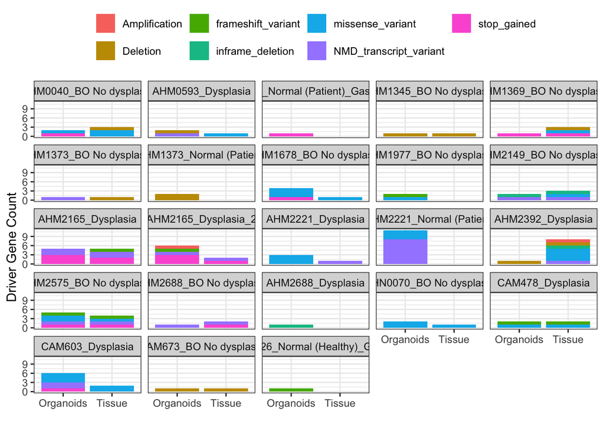

```r
muts.oac %>%
  group_by(`Patient ID`, `Organoid or Tissue`, mutationType) %>%
  summarise(count = n()) %>%
  ggplot(aes(x = `Organoid or Tissue`, y = count, fill = mutationType)) +
  theme_bw() + geom_bar(stat = 'identity') + facet_wrap(~`Patient ID`) +
  theme(legend.position = 'top', legend.title = element_blank()) +
  labs(x='', y='Driver Gene Count')
```

# 2 Prepare additional information

Now we can start collating additional functional genomic information.

## 2.1 Tumour Mutation Burden

Conveniently, total SNV and indel counts are stored in .txt files as outputted from strelka processing. Therefore, all we need to do is collate these files. Fortunately, these are saved in the same order as our VEP files, and therefore can be filtered as such

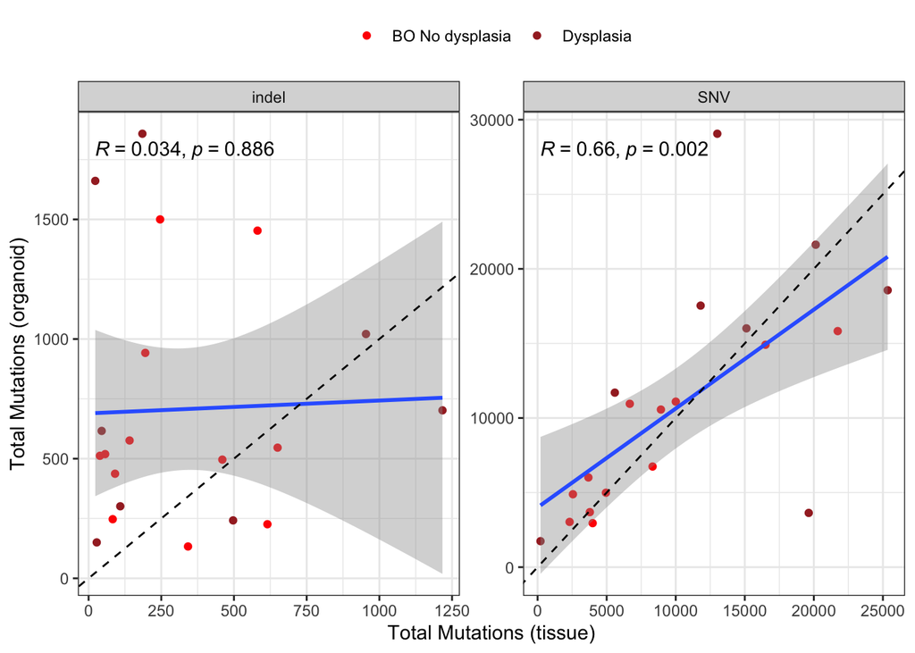

```r
# List .txt files
files.tmb <- list.files('Data/strelka', pattern = 'txt$', recursive = TRUE, full.names = TRUE)

# For each file, extract the sequence ID from the file name, save SNV/indel type, and extract TMB
df.tmb <- data.frame()

for (file in files.tmb) {

  sequence_id <- strsplit(strsplit(file, split='/')[[1]][3], split='_vs_')[[1]][1]
  mut_type <- ifelse(grepl(pattern = 'indel', file), 'indel', 'SNV')
  tmb <- read.table(file)[1,1]

  df.tmb.i <- data.frame(sequence_id, mut_type, tmb)
  df.tmb <- rbind(df.tmb, df.tmb.i)

}

# Combine with metdata (for the sake of initial comparison)
df.tmb <- merge(x = df.tmb, y = meta[,c('index_corrected','Patient ID','Organoid or Tissue')],
                by.x = 'sequence_id', by.y = 'index_corrected')

df.tmb %>%
  dplyr::select(-sequence_id) %>%
  mutate(Stage = factor(sapply(`Patient ID`, function(x) strsplit(x,split='_')[[1]][2]),
                        levels = c('BO No dysplasia','Dysplasia'))) %>%
  filter(!is.na(Stage)) %>%
  pivot_wider(names_from = `Organoid or Tissue`, values_from = tmb) %>%
  ggplot(aes(x = Tissue, y = Organoids)) + theme_bw() +
  geom_point(aes(color = Stage)) + geom_smooth(method = 'lm') + stat_cor(p.accuracy=0.001)  +
  theme(legend.position = 'top', legend.title = element_blank()) +
  labs(x = 'Total Mutations (tissue)', y = 'Total Mutations (organoid)') +
  scale_color_manual(values = c('red1','brown')) +
  geom_abline(col = 'black', linetype = 'dashed', slope = 1, intercept = 0) +
  facet_wrap(~mut_type, scales = 'free')
```

```r
ggsave(filename = 'Results/OrganoidsGastricBO_concordanceTMB.pdf', height = 4)
```

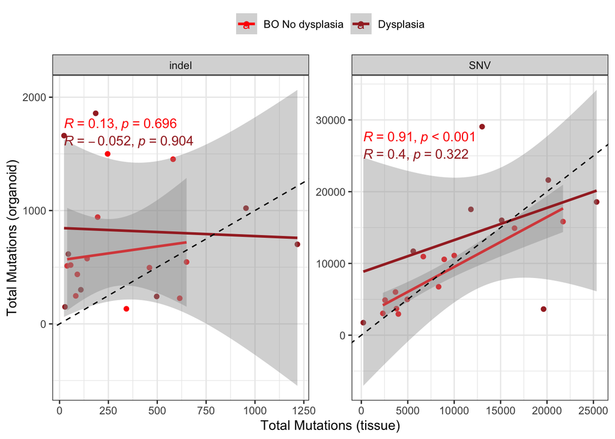

```r
df.tmb %>%
  dplyr::select(-sequence_id) %>%
  mutate(Stage = factor(sapply(`Patient ID`, function(x) strsplit(x,split='_')[[1]][2]),
                        levels = c('BO No dysplasia','Dysplasia'))) %>%
  filter(!is.na(Stage)) %>%
  pivot_wider(names_from = `Organoid or Tissue`, values_from = tmb) %>%
  ggplot(aes(x = Tissue, y = Organoids, color = Stage)) + theme_bw() +
  geom_point() + geom_smooth(method = 'lm') + stat_cor(p.accuracy=.001) +
  theme(legend.position = 'top', legend.title = element_blank()) +
  labs(x = 'Total Mutations (tissue)', y = 'Total Mutations (organoid)') +
  scale_color_manual(values = c('red1','brown')) +
  geom_abline(col = 'black', linetype = 'dashed', slope = 1, intercept = 0) +
  facet_wrap(~mut_type, scales = 'free')
```

```r
ggsave(filename = 'Results/OrganoidsGastricBO_concordanceTMB_byStage.pdf', height = 4)
# Finally, save total TMB values
df.tmb <- df.tmb %>%
  group_by(sequence_id, `Patient ID`, `Organoid or Tissue`) %>%
  summarise(TMB = sum(tmb)) %>%
  mutate(TMB = TMB/3100)
```

```
## `summarise()` has regrouped the output.
## ℹ Summaries were computed grouped by sequence_id, Patient ID, and Organoid or
##   Tissue.
## ℹ Output is grouped by sequence_id and Patient ID.
## ℹ Use `summarise(.groups = "drop_last")` to silence this message.
## ℹ Use `summarise(.by = c(sequence_id, Patient ID, Organoid or Tissue))` for
##   per-operation grouping (`?dplyr::dplyr_by`) instead.
```

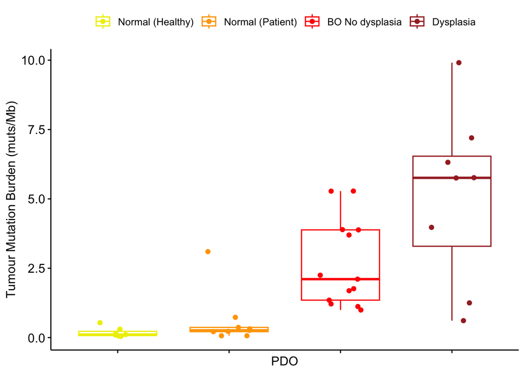

```r
# Out of curiosity, plot change in TMB in organoids across groups
df.tmb_plot <- df.tmb %>%
  filter(`Organoid or Tissue` == 'Organoids')
df.tmb_plot$Group <- factor(sapply(df.tmb_plot$`Patient ID`, function(x) strsplit(x,split='_')[[1]][2]),
                            levels = c('Normal (Healthy)','Normal (Patient)','BO No dysplasia','Dysplasia'))
ggboxplot(df.tmb_plot, x = 'Group', y = 'TMB', add = 'jitter', color = 'Group') +
  theme(legend.title = element_blank(), axis.text.x = element_blank()) +
  scale_color_manual(values = c('yellow2','orange','red1','brown')) +
  labs(x = 'PDO', y = 'Tumour Mutation Burden (muts/Mb)')
```

```r
ggsave(filename = 'Results/OrganoidsGastricBO_TMBbyStatus_PDO.pdf', height = 4)
```

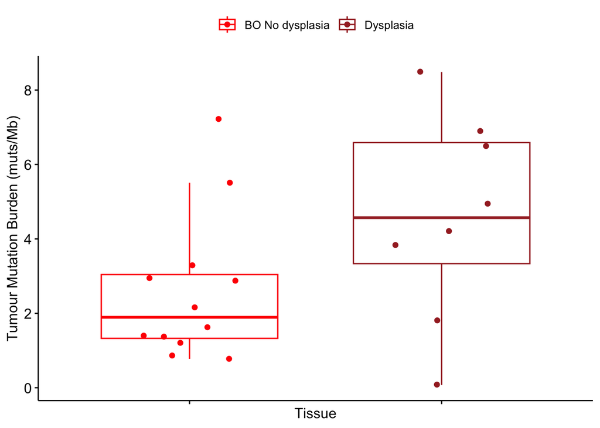

```r
# ...and in tissues
df.tmb_plot <- df.tmb %>%
  filter(`Organoid or Tissue` == 'Tissue')
df.tmb_plot$Group <- factor(sapply(df.tmb_plot$`Patient ID`, function(x) strsplit(x,split='_')[[1]][2]),
                            levels = c('BO No dysplasia','Dysplasia'))
ggboxplot(df.tmb_plot, x = 'Group', y = 'TMB', add = 'jitter', color = 'Group') +
  theme(legend.title = element_blank(), axis.text.x = element_blank()) +
  scale_color_manual(values = c('red1','brown')) +
  labs(x = 'Tissue', y = 'Tumour Mutation Burden (muts/Mb)')
```

```r
ggsave(filename = 'Results/OrganoidsGastricBO_TMBbyStatus_Tissue.pdf', height = 4, width = 4)

# Print mean TMB across groups and separated by Organoids/Tissues
df.tmb %>%
  mutate(Group = sapply(`Patient ID`, function(x) strsplit(x,split='_')[[1]][2])) %>%
  # filter(Group %in% c('BO No dysplasia','Dysplasia')) %>%
  group_by(`Organoid or Tissue`, Group) %>% summarise(`median TMB` = median(TMB))
```

```
## `summarise()` has regrouped the output.
## ℹ Summaries were computed grouped by Organoid or Tissue and Group.
## ℹ Output is grouped by Organoid or Tissue.
## ℹ Use `summarise(.groups = "drop_last")` to silence this message.
## ℹ Use `summarise(.by = c(Organoid or Tissue, Group))` for per-operation
##   grouping (`?dplyr::dplyr_by`) instead.
```

```
## # A tibble: 6 × 3
## # Groups:   Organoid or Tissue [2]
##   `Organoid or Tissue` Group            `median TMB`
##   <chr>                <chr>                   <dbl>
## 1 Organoids            BO No dysplasia         2.11
## 2 Organoids            Dysplasia               5.76
## 3 Organoids            Normal (Healthy)        0.110
## 4 Organoids            Normal (Patient)        0.263
## 5 Tissue               BO No dysplasia         1.89
## 6 Tissue               Dysplasia               4.57
```

## 2.2 Purity/ploidy

These values are calculated using ASCAT output, and are saved in the ploidy files generated earlier. We can save this in the data frame ‘df.ascatAnno’.

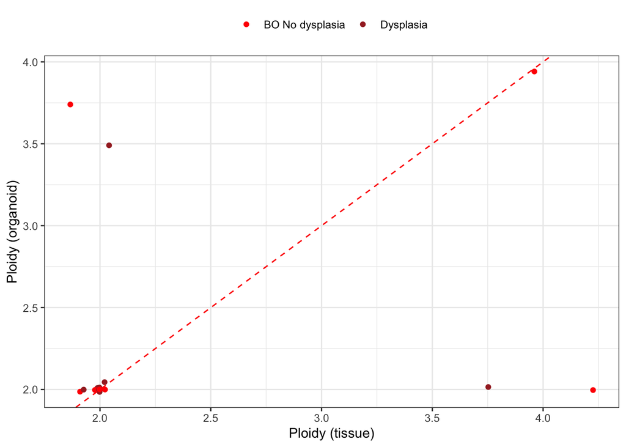

```r
df.ascatAnno <- data.frame()

for (file in files.ploidy) {

  sequence_id <- strsplit(strsplit(file, split='/')[[1]][3], split='_vs_')[[1]][1]

  file.ploidy.i <- read.delim(file, header = FALSE, sep = ' ')
  ploidy.i <- file.ploidy.i$V2[file.ploidy.i$V1 == 'Ploidy']
  purity.i <- 1 - file.ploidy.i$V2[file.ploidy.i$V1 == 'NormalContamination']

  df.ascatAnno.i <- data.frame(sequence_id, Ploidy = ploidy.i, Purity = purity.i)
  df.ascatAnno <- rbind(df.ascatAnno, df.ascatAnno.i)

}

# Combine with metdata (for the sake of initial comparison)
df.ascatAnno <- merge(x = df.ascatAnno, y = meta[,c('index_corrected','Patient ID','Organoid or Tissue','Passage')],
                      by.x = 'sequence_id', by.y = 'index_corrected')

df.ascatAnno %>%
  dplyr::select(`Patient ID`, `Organoid or Tissue`, Ploidy) %>%
  mutate(Stage = factor(sapply(`Patient ID`, function(x) strsplit(x,split='_')[[1]][2]),
                        levels = c('BO No dysplasia','Dysplasia'))) %>%
  filter(!is.na(Stage)) %>%
  pivot_wider(names_from = `Organoid or Tissue`, values_from = Ploidy) %>%
  ggplot(aes(x = Tissue, y = Organoids, color = Stage)) + theme_bw() +
  geom_point() +
  # geom_smooth(method = 'lm') +
  labs(x = 'Ploidy (tissue)', y = 'Ploidy (organoid)') +
  scale_color_manual(values = c('red1','brown'))+
  geom_abline(col = 'red', linetype = 'dashed', slope = 1, intercept = 0) +
  theme(legend.position = 'top', legend.title = element_blank())
```

```r
ggsave(filename = 'Results/OrganoidsGastricBO_concordancePloidy.pdf',
       width = 5, height = 5)
```

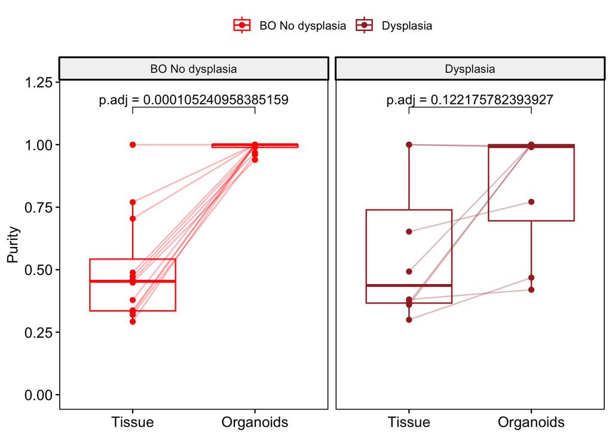

```r
# df.ascatAnno %>%
#   dplyr::select(`Patient ID`, `Organoid or Tissue`, Purity) %>%
#   mutate(Stage = factor(sapply(`Patient ID`, function(x) strsplit(x,split='_')[[1]][2]),
#                         levels = c('BO No dysplasia', 'Dysplasia'))) %>%
#   pivot_wider(names_from = `Organoid or Tissue`, values_from = Purity) %>%
#   ggplot(aes(x = Tissue, y = Organoids, color = Stage)) + theme_bw() +
#   geom_point() + xlim(c(0,1)) + ylim(c(0,1)) +
#   labs(x = 'Purity (tissue)', y = 'Purity (organoid)') +
#   theme(legend.position = 'top', legend.title = element_blank())
# ggsave(filename = 'Results/OrganoidsGastricBO_concordancePurity.pdf')

df.ascatAnno %>%
  dplyr::select(`Patient ID`, `Organoid or Tissue`, Purity) %>%
  mutate(Stage = factor(sapply(`Patient ID`, function(x) strsplit(x,split='_')[[1]][2]),
                        levels = c('BO No dysplasia', 'Dysplasia')),
         Organoid_or_Tissue = factor(`Organoid or Tissue`,
                                     levels = c('Tissue','Organoids'))) %>%
  filter(!is.na(Stage)) -> df.ascatAnno_purity

# Compare PDO vs tissue - separated by Stage
df.ascatAnno_purity[,-2] %>%
  group_by(Stage) %>%
  pairwise_wilcox_test(Purity ~ Organoid_or_Tissue, p.adjust.method = 'BH') %>%
  add_xy_position(x = 'Organoid_or_Tissue') %>%
  mutate(p.adj_label = sapply(p.adj, function(x) paste0('p.adj = ',x))) -> stat.test_byStage
ggboxplot(df.ascatAnno_purity, x = 'Organoid or Tissue', y = 'Purity',
          color = 'Stage', facet.by = 'Stage') + ylim(c(0,1.2)) +
  stat_pvalue_manual(stat.test_byStage, label = 'p.adj_label', y.position = 1.15) +
  geom_point(aes(color = Stage)) + geom_line(aes(group = `Patient ID`, color = Stage), alpha = .3) +
  scale_color_manual(values = c('red1','brown')) +
  theme(legend.title = element_blank(), axis.title.x = element_blank())
```

```r
ggsave(filename = 'Results/OrganoidsGastricBO_concordancePurity_byStage.pdf', height = 4.5)
```

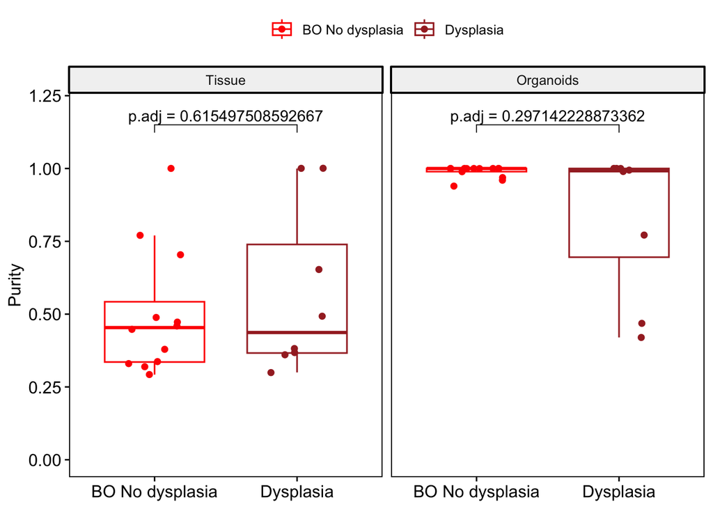

```r
# Compare Dysplasia vs NDBE - separated by Organoid/Tissue
df.ascatAnno_purity %>%
  group_by(Organoid_or_Tissue) %>%
  wilcox_test(Purity ~ Stage) %>%
  adjust_pvalue(method = 'BH') %>% add_significance('p.adj') %>%
  add_xy_position(x = 'Stage') %>%
  mutate(p.adj_label = sapply(p.adj, function(x) paste0('p.adj = ',x))) -> stat.test_byOrgTissue
ggboxplot(df.ascatAnno_purity, x = 'Stage', y = 'Purity',
          add = 'jitter', color = 'Stage', facet.by = 'Organoid_or_Tissue') + ylim(c(0,1.2)) +
  stat_pvalue_manual(stat.test_byOrgTissue, label = 'p.adj_label', y.position = 1.15) +
  scale_color_manual(values = c('red1','brown')) +
  theme(legend.title = element_blank(), axis.title.x = element_blank())
```

```r
ggsave(filename = 'Results/OrganoidsGastricBO_concordancePurity_byOrgTissue.pdf', height = 4.5)
# Print mean purities across organoid/tissue and stage
df.ascatAnno_purity %>%
  group_by(`Organoid or Tissue`, Stage) %>%
  summarise(`median Purity` = median(Purity))
```

```
## `summarise()` has regrouped the output.
## ℹ Summaries were computed grouped by Organoid or Tissue and Stage.
## ℹ Output is grouped by Organoid or Tissue.
## ℹ Use `summarise(.groups = "drop_last")` to silence this message.
## ℹ Use `summarise(.by = c(Organoid or Tissue, Stage))` for per-operation
##   grouping (`?dplyr::dplyr_by`) instead.
```

```
## # A tibble: 4 × 3
## # Groups:   Organoid or Tissue [2]
##   `Organoid or Tissue` Stage           `median Purity`
##   <chr>                <fct>                     <dbl>
## 1 Organoids            BO No dysplasia           1
## 2 Organoids            Dysplasia                 0.992
## 3 Tissue               BO No dysplasia           0.454
## 4 Tissue               Dysplasia                 0.437
```

## 2.3 HRD index score

We can also calculate the HRD Myriad index score, using the scarHRD R package. Here, we are using this primarily as a generic measure of chromosomal instability, since its association with HRD pan-cancer and with oesophageal adenocarcinoma itself is debatable.

For this we require the Caveman output (stored in the files.caveman object) and sample statistics information for ploidy normalisation (stored in the files.ploidy object).

The first step is input creation, where we extract the following information for each sample:

- SampleID
- Chromosome, Start position, and End position
- Probe count (unknown here)
- Total copy number, and Minor (A) and Major (B) copy number
- Ploidy and Contamination

```r
# We must start by generating scarHRD info, which we can store.
for (i in 1:length(files.caveman)) {

  cave.i <- read.csv(files.caveman[i])
  caveInfo.i <- read.delim(files.ploidy[i], header = FALSE, sep = ' ')
  sequence_id.i <- strsplit(strsplit(files.caveman[i],split='/')[[1]][3],split='_vs_')[[1]][1]

  input.i <- data.frame(
    SampleID = sequence_id.i,
    Chromosome = as.numeric(cave.i$Chromosome),
    Start_position = cave.i$Start,
    End_position = cave.i$End,
    num_probes = NA,
    total_cn = cave.i$Total_CN,
    A_cn = cave.i$Minor_CN,
    B_cn = cave.i$Total_CN - cave.i$Minor_CN,
    ploidy = caveInfo.i$V2[caveInfo.i$V1 == 'Ploidy'],
    contamination = caveInfo.i$V2[caveInfo.i$V1 == 'NormalContamination']
  )

  input.i <- input.i %>% filter(!is.na(Chromosome)) # remove regions outside of chromosomes 1-22
  write.table(input.i, file = paste0('Results/scarHRD/input/scarHRD_input_',sequence_id.i,'.txt'),
              sep='\t')

}
```

Now that we have generated input files, we can apply the scar_score() function to read htem in and calculate the respective HRD index score.

```r
files.scarHRD_input <- list.files(path = 'Results/scarHRD/input', full.names = TRUE, recursive = TRUE)

df.scarHRD <- data.frame()
for (file in files.scarHRD_input) {
  scarHRD.i <- scar_score(file, reference = 'grch37', output = 'Results/scarHRD/output') %>%
    as.data.frame
  scarHRD.i$sequence_id <- strsplit(
    strsplit(strsplit(file,split='/')[[1]][4],split='input_')[[1]][2],split='.txt')[[1]][1]
  df.scarHRD <- rbind(df.scarHRD, scarHRD.i)
}
```

[output not shown]

[output cut: 8 more lines]

[output not shown]

Now we can compare HRD index scores across organoids and tissues to check if chromosomal instability is retained.

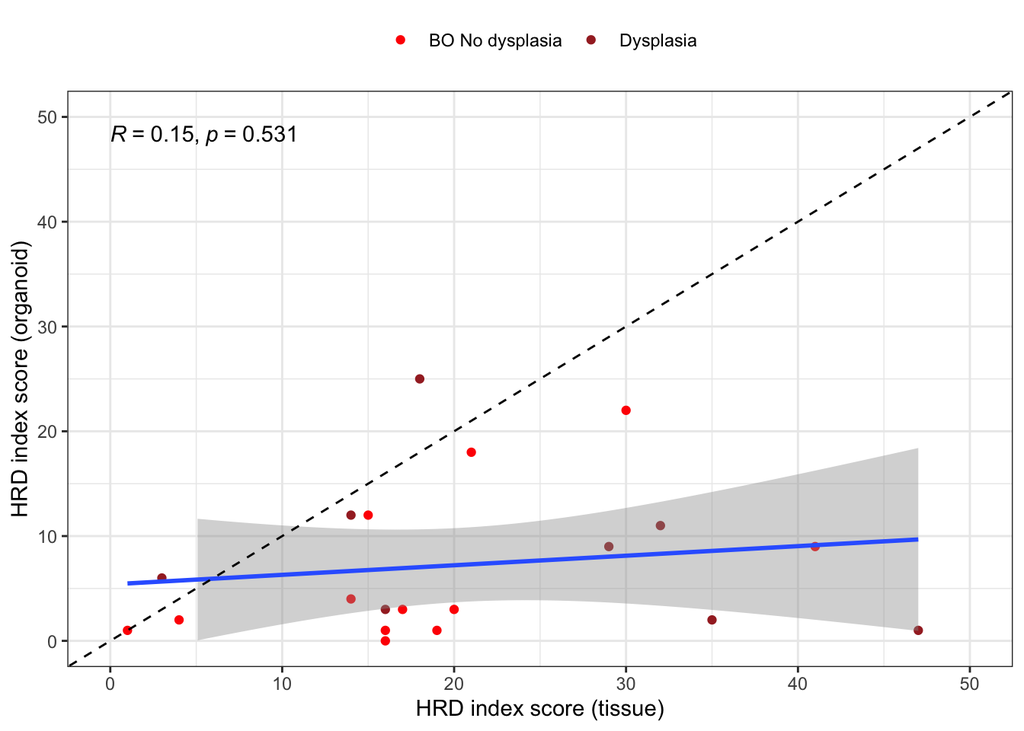

```r
# Add metadata
df.scarHRD <- merge(x = df.scarHRD, y = meta[,c('index_corrected','Patient ID','Organoid or Tissue')],
                    by.x = 'sequence_id', by.y = 'index_corrected')

# # Plot HRD index score formation per sample
# df.scarHRD %>%
#   dplyr::select(-`HRD-sum`) %>%
#   pivot_longer(cols = c(HRD, `Telomeric AI`, LST), names_to = 'HRD_measure', values_to = 'score') %>%
#   ggplot(aes(x = `Organoid or Tissue`, y = score, fill = HRD_measure)) + theme_bw() +
#   geom_bar(stat = 'identity') +
#   theme(legend.position = 'top') +
#   labs(x='',y = 'HRD index score') +
#   facet_wrap(~`Patient ID`)

# Correlate full HRD score across matched tissue/organoid pairs
df.scarHRD %>%
  dplyr::select(`Patient ID`, `Organoid or Tissue`, `HRD-sum`) %>%
  mutate(Stage = sapply(`Patient ID`, function(x) strsplit(x,split='_')[[1]][2])) %>%
  filter(Stage %in% c('BO No dysplasia','Dysplasia')) %>%
  pivot_wider(names_from = `Organoid or Tissue`, values_from = `HRD-sum`) %>%
  ggplot(aes(x = Tissue, y = Organoids)) +
  theme_bw() + geom_point(aes(color = Stage)) + geom_smooth(method = 'lm') + stat_cor(p.accuracy=.001) +
  theme(legend.position = 'top', legend.title = element_blank()) +
  scale_color_manual(values = c('red1','brown')) +
  geom_abline(col = 'black', linetype = 'dashed', slope = 1, intercept = 0) +
  xlim(c(0,50)) + ylim(c(0,50)) +
  labs(x = 'HRD index score (tissue)', y = 'HRD index score (organoid)')
```

```r
ggsave(filename = 'Results/OrganoidsGastricBO_concordanceHRDscore.pdf',
       height = 5, width = 5)
```

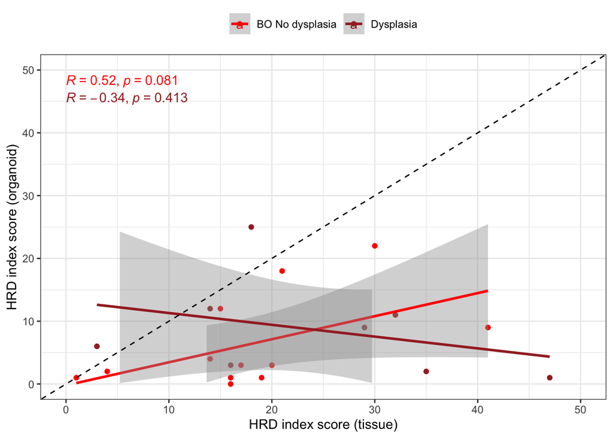

```r
df.scarHRD %>%
  dplyr::select(`Patient ID`, `Organoid or Tissue`, `HRD-sum`) %>%
  mutate(Stage = sapply(`Patient ID`, function(x) strsplit(x,split='_')[[1]][2])) %>%
  filter(Stage %in% c('BO No dysplasia','Dysplasia')) %>%
  pivot_wider(names_from = `Organoid or Tissue`, values_from = `HRD-sum`) %>%
  ggplot(aes(x = Tissue, y = Organoids, color = Stage)) +
  theme_bw() + geom_point() + geom_smooth(method = 'lm') + stat_cor(p.accuracy=.001) +
  theme(legend.position = 'top', legend.title = element_blank()) +
  scale_color_manual(values = c('red1','brown')) +
  geom_abline(col = 'black', linetype = 'dashed', slope = 1, intercept = 0) +
  xlim(c(0,50)) + ylim(c(0,50)) +
  labs(x = 'HRD index score (tissue)', y = 'HRD index score (organoid)')
```

```r
ggsave(filename = 'Results/OrganoidsGastricBO_concordanceHRDscore_byStage.pdf',
       height = 5, width = 5)
```

```r
# # We can also compare how HRD scores change throughout progression in the organoids
# df.scarHRD_plot <- df.scarHRD %>% filter(`Organoid or Tissue` == 'Organoids')
# # df.scarHRD_plot$Group <- factor(sapply(df.scarHRD_plot$`Patient ID`, function(x)
# #   strsplit(x,split='_')[[1]][2]),
# #   levels = c('Normal (Healthy)','Normal (Patient)','BO No dysplasia','Dysplasia'))
# df.scarHRD_plot$Group <- sapply(df.scarHRD_plot$`Patient ID`, function(x) strsplit(x,split='_')[[1]][2])
# df.scarHRD_plot <- df.scarHRD_plot %>% filter(Group %in% c('BO No dysplasia','Dysplasia'))
# names(df.scarHRD_plot)[which(names(df.scarHRD_plot) == 'HRD-sum')] <- 'HRD score'
# ggboxplot(df.scarHRD_plot, x = 'Group', y = 'HRD score', add = 'jitter', color = 'Group')  +
#   theme(legend.title = element_blank(), axis.text.x = element_blank()) +
#   labs(x = '', y = 'HRD index score') +
#   stat_compare_means()
# ggsave(filename = 'Results/OrganoidsGastricBO_HRDbyStatus.pdf',
#        width = 5, height = 5)
```

## 2.4 Mutational signatures

Finally, we fit mutational signatures to the full SNV profiles of each sample. It is worth mentioning that the robustness of signature analysis in general decreases with lower mutation counts, and so the results for the normal gastric orgaoids should be taken with a pinch of salt.

Again, we fit the OAC-linked signatures.

```r
# Load VCF files. We can save the VAFs too, as these will come in handy going forward.
files.vcf <- list.files(path = 'Data/strelka', pattern = '.vcf$', recursive = TRUE, full.names = TRUE)

vcfs.all <- data.frame()
for (vcf in files.vcf) {

  # 1. Load data
  vcf.i <- read.vcfR(vcf, verbose = FALSE)@fix %>% as.data.frame

  # 2. Extract depth and VAF (will be useful going forward)
  vcf.i$DEPTH <- NA
  vcf.i$VAF <- NA

  if (grepl(pattern = '.snp.pass.vcf',vcf)) {
    index.depth <- which(grepl(pattern = 'Depth', strsplit(vcf.i$INFO[1],split=';')[[1]]))
    vcf.i$DEPTH <- sapply(vcf.i$INFO, function(x) as.numeric(strsplit(
      strsplit(x,split=';')[[1]][index.depth],split='=')[[1]][2]))

    index.vaf <- which(grepl(pattern = 'VariantAlleleFrequency', strsplit(vcf.i$INFO[1],split=';')[[1]]))
    vcf.i$VAF <- sapply(vcf.i$INFO, function(x) as.numeric(strsplit(
      strsplit(x,split=';')[[1]][index.vaf],split='=')[[1]][2]))
  }

  # 3. Add sequence_id
  vcf.i$sequence_id <- strsplit(strsplit(vcf, split='/')[[1]][3], split='_vs_')[[1]][1]

  # 4. Save output
  vcfs.all <- rbind(vcfs.all, vcf.i[,c('CHROM','POS','REF','ALT','DEPTH','VAF','sequence_id')])

}

# Generate deconstructSigs input
vcfs.all <- vcfs.all %>% filter(CHROM %in% paste0('chr',1:22))
vcfs.all$POS <- vcfs.all$POS %>% as.numeric

input.deconstruct_sigs <- mut.to.sigs.input(
  mut.ref = vcfs.all,
  sample.id = 'sequence_id',
  chr = 'CHROM',
  pos = 'POS',
  ref = 'REF',
  alt = 'ALT',
  bsg = BSgenome.Hsapiens.UCSC.hg19
)
```

Fit signatures

```r
# Prepare matrix of established signatures (GRCh37, v3.3.1)
sigs.hg37 <- read.table('Results/COSMIC_v3.3.1_SBS_GRCh37.txt', header = TRUE, row.names = 1)
sigs.hg37 <- as.data.frame(t(sigs.hg37))
sigs.hg37 <- sigs.hg37[,colnames(signatures.cosmic)] # reorders columns to fit deconstructSigs default

# Establish extracted signatures
sigs.extracted <- paste0('SBS',c(1,2,5,8,13,'17a','17b',18,40,93))

# Run deconstructSigs
sigs.extracted_complete <- data.frame()

for (sample in rownames(input.deconstruct_sigs)) {

  sigs.i <- whichSignatures(tumor.ref = input.deconstruct_sigs,
                            signatures.ref = sigs.hg37[sigs.extracted,],
                            sample.id = sample,
                            tri.counts.method = 'default',
                            contexts.needed = TRUE,
                            signature.cutoff = 0.02)
  sigs.i$weights$SBS_unknown <- sigs.i$unknown
  sigs.extracted_complete <- rbind(sigs.extracted_complete, sigs.i$weights)

}
```

For starters, we can compare overall signature profiles and determine concordance across signature profiles within organoid-tissue pairs

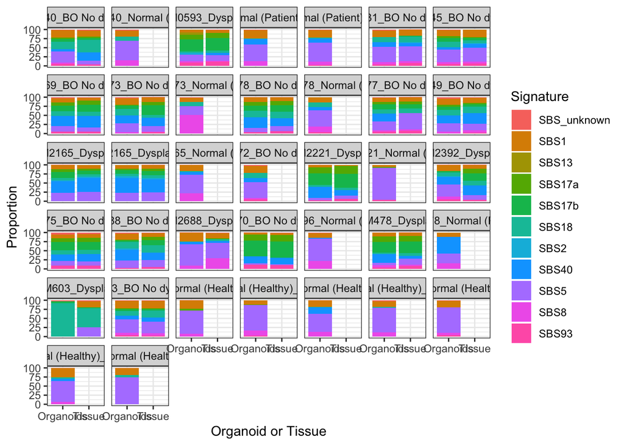

```r
# Add sequence_id column and merge with metadata
sigs.extracted_complete$sequence_id <- rownames(sigs.extracted_complete)
sigs.extracted_complete <- merge(x = sigs.extracted_complete,
                                 y = meta[,c('index_corrected','Patient ID','Organoid or Tissue')],
                                 by.x = 'sequence_id', by.y = 'index_corrected')

# Plot full signature profiles
sigs.extracted_complete %>%
  pivot_longer(cols = c(SBS1,SBS2,SBS5,SBS8,SBS13,SBS17a,SBS17b,SBS18,SBS40,SBS93,SBS_unknown), names_to = 'Signature', values_to = 'Proportion') %>%
  mutate(Proportion = 100*Proportion) %>%
  ggplot(aes(x = `Organoid or Tissue`, y = Proportion, fill = Signature)) + theme_bw() +
  geom_bar(stat = 'identity') + facet_wrap(~`Patient ID`)
```

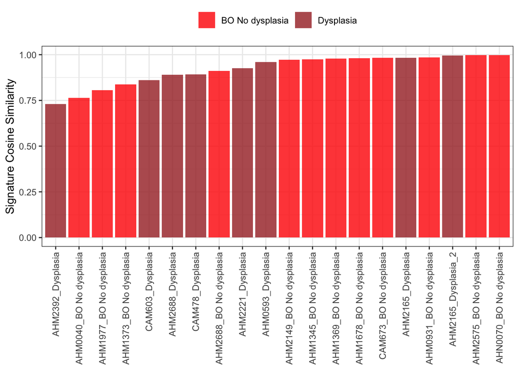

```r
# Calculate cosine similarity, initially by separating sigs.extracted complete into organoid and tissue profiles
sigs.tissue <- sigs.extracted_complete %>% filter(`Organoid or Tissue` == 'Tissue')
sigs.organoid <- sigs.extracted_complete %>% filter(`Organoid or Tissue` == 'Organoids')

joint_cases <- intersect(sigs.tissue$`Patient ID`, sigs.organoid$`Patient ID`)
cosineSims <- c()

for (case in joint_cases) {

  tissue.sig <- sigs.tissue[which(sigs.tissue$`Patient ID` == case), grepl(pattern = 'SBS',names(sigs.tissue))]
  organoid.sig <- sigs.organoid[which(sigs.organoid$`Patient ID` == case), grepl(pattern = 'SBS',names(sigs.organoid))]

  cosineSim.i <- cosine(as.numeric(tissue.sig), as.numeric(organoid.sig))[1,1]
  cosineSims <- c(cosineSims, cosineSim.i)

}

# Order cosine similarities for plotting purposes
cosineSims <- data.frame(cosineSims, case = joint_cases)
cosineSims <- cosineSims %>% arrange(cosineSims)
cosineSims$case <- factor(cosineSims$case, levels= cosineSims$case)
cosineSims$Stage <- factor(sapply(as.character(cosineSims$case),
                                  function(x) strsplit(x,split='_')[[1]][2]),
                           levels = c('BO No dysplasia','Dysplasia'))
rownames(cosineSims) <- cosineSims$case

ggplot(cosineSims, aes(x = case, y = cosineSims, fill = Stage)) +
  theme_bw() + geom_bar(stat = 'identity', alpha = .8) +
  theme(axis.text.x = element_text(angle = 90, vjust = 0.5, hjust=1)) +
  theme(axis.title.x = element_blank(),
        legend.position = 'top', legend.title = element_blank()) +
  scale_fill_manual(values = c('red1','brown')) +
  labs(x = 'Case ID', y = 'Signature Cosine Similarity')
```

```r
ggsave(filename = 'Results/OrganoidsGastricBO_signatureCosineSimilarity.pdf', height = 5)
```

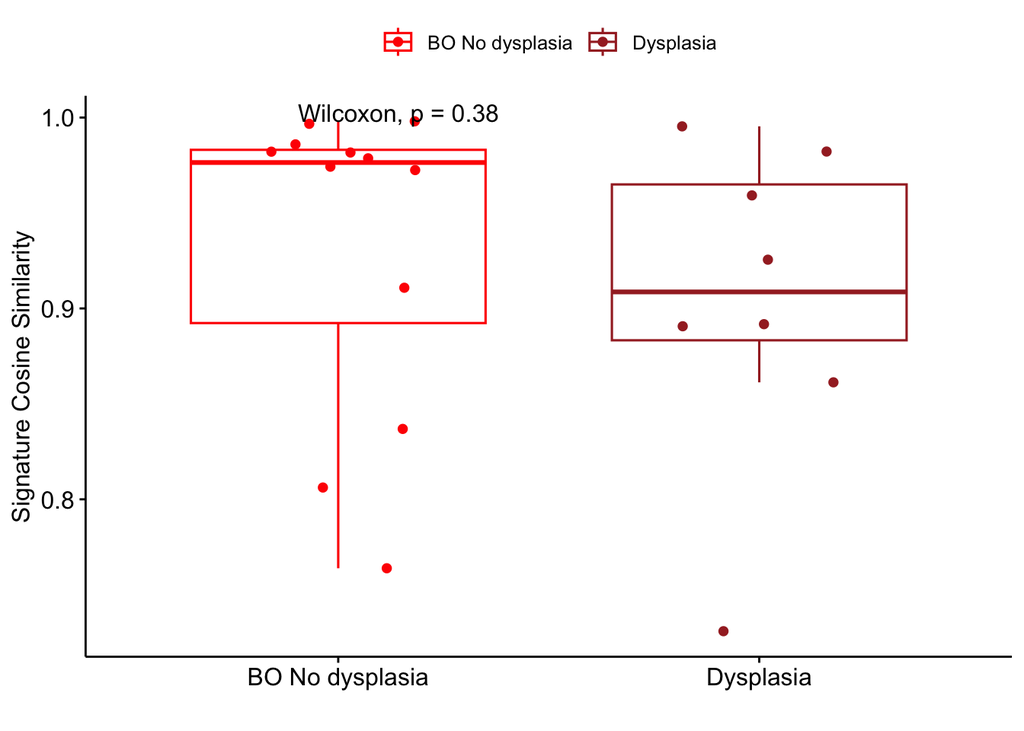

```r
# Check differences in cosine similaities between NDBE and dysplasia
ggboxplot(cosineSims, x = 'Stage', y = 'cosineSims', add = 'jitter', color = 'Stage') +
  stat_compare_means() + theme(legend.title = element_blank()) +
  scale_color_manual(values = c('red1','brown')) +
  labs(x = '', y = 'Signature Cosine Similarity')
```

```r
ggsave(filename = 'Results/OrganoidsGastricBO_signatureCosineSimilarity_byStage.pdf', height = 5)
cosineSims %>% summarise(`median cosine sim` = median(cosineSims))
```

```
##   median cosine sim
## 1          0.965844
```

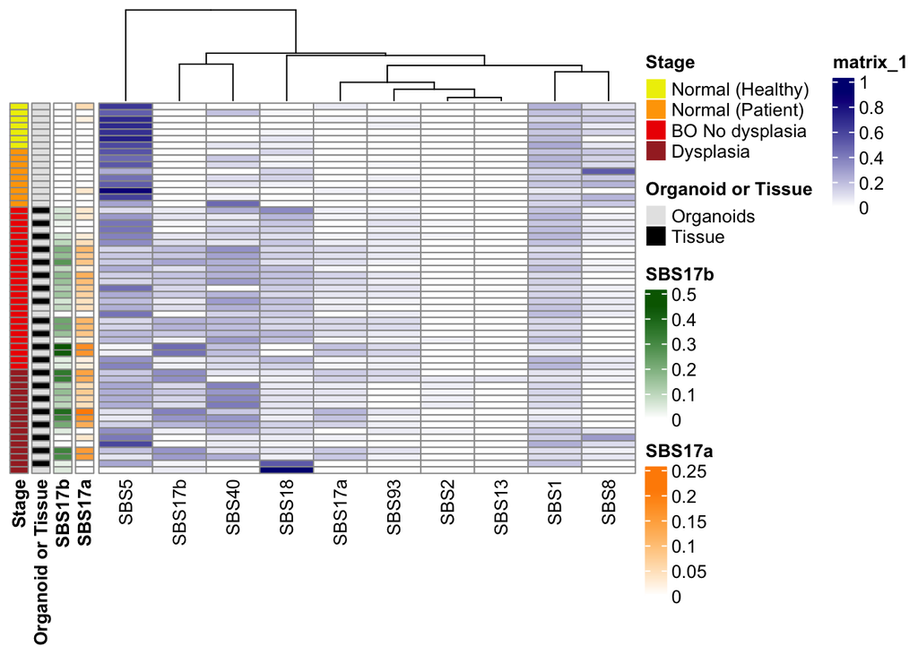

```r
## Compare matched tissues/organoids (use sigs.extracted_complete)
sigs.complete <- sigs.extracted_complete

# Start by just plotting them by patient
sigs.complete$Stage <- factor(sapply(sigs.complete$`Patient ID`, function(x) strsplit(x, split='_')[[1]][2]),
                              levels = c('Normal (Healthy)','Normal (Patient)','BO No dysplasia','Dysplasia'))
sigs.complete <- sigs.complete %>% arrange(Stage, `Patient ID`, desc(`Organoid or Tissue`))
rownames(sigs.complete) <- sigs.complete$sequence_id
sigs.ann <- sigs.complete[,c('SBS17a','SBS17b','Organoid or Tissue','Stage')]

cols_scale <- colorRampPalette(colors = c('white','navy'))(1000)
ann_colors <- list(
  Stage = c(`Normal (Healthy)` = 'yellow2', `Normal (Patient)` = 'orange',
            `BO No dysplasia` = 'red2', Dysplasia = 'brown'),
  `Organoid or Tissue` = c(Organoids = 'gray90', Tissue = 'black'),
  SBS17a = colorRampPalette(c('white','darkorange'))(100),
  SBS17b = colorRampPalette(c('white','darkgreen'))(100)
)

# pdf('Results/OrganoidsBO_SignatureHeatmap.pdf')
pheatmap(sigs.complete[,2:11],
         cluster_rows = FALSE, annotation_row = sigs.ann, annotation_colors = ann_colors,
         show_rownames = FALSE, color = cols_scale)
```

```r
# dev.off()
```

Finally, we shall do a direct comparison and save the results for the oncoplot

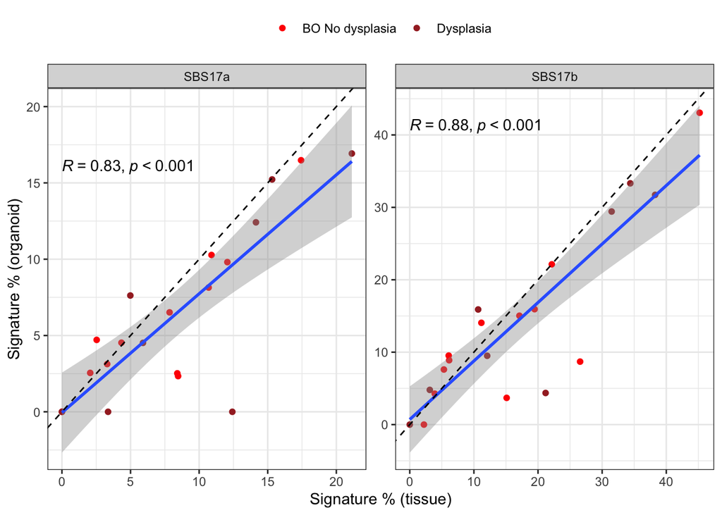

```r
# Correlation of Signature 17 between tissues and organoids
sigs.extracted_complete %>%
  dplyr::select(`Patient ID`, `Organoid or Tissue`, SBS17a, SBS17b) %>%
  mutate(Stage = factor(sapply(`Patient ID`, function(x)
    strsplit(x,split='_')[[1]][2]),
    levels = c('BO No dysplasia','Dysplasia'))) %>%
  filter(!is.na(Stage)) %>%
  pivot_longer(cols = c(SBS17a, SBS17b), names_to = 'Sig17', values_to = 'Proportion') %>%
  mutate(Proportion = 100 * Proportion) %>%
  pivot_wider(names_from = `Organoid or Tissue`, values_from = Proportion) %>%
  ggplot(aes(x = Tissue, y = Organoids)) + theme_bw() +
  geom_point(aes(color = Stage)) + geom_smooth(method = 'lm') + stat_cor(p.accuracy=.001) +
  geom_abline(col = 'black', linetype = 'dashed', slope = 1, intercept = 0) +
  scale_color_manual(values = c('red1','brown')) +
  labs(x = 'Signature % (tissue)', y = 'Signature % (organoid)') +
  facet_wrap(~Sig17, scales = 'free') +
  theme(legend.position = 'top', legend.title = element_blank())
```

```r
ggsave(filename = 'Results/OrganoidsGastricBO_concordanceSignature17.pdf', height = 5)
```

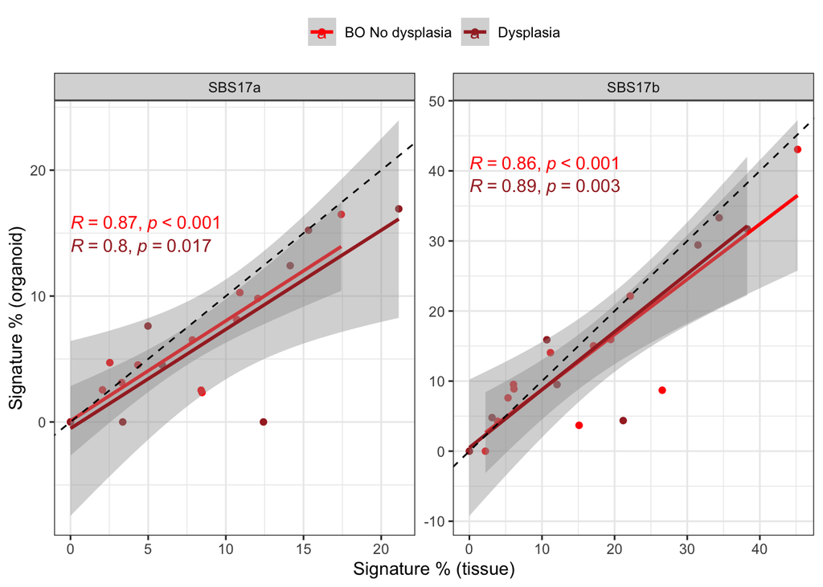

```r
# ...and also by stage
sigs.extracted_complete %>%
  dplyr::select(`Patient ID`, `Organoid or Tissue`, SBS17a, SBS17b) %>%
  mutate(Stage = factor(sapply(`Patient ID`, function(x)
    strsplit(x,split='_')[[1]][2]),
    levels = c('BO No dysplasia','Dysplasia'))) %>%
  filter(!is.na(Stage)) %>%
  pivot_longer(cols = c(SBS17a, SBS17b), names_to = 'Sig17', values_to = 'Proportion') %>%
  mutate(Proportion = 100 * Proportion) %>%
  pivot_wider(names_from = `Organoid or Tissue`, values_from = Proportion) %>%
  ggplot(aes(x = Tissue, y = Organoids, color = Stage)) + theme_bw() +
  geom_point() + geom_smooth(method = 'lm') + stat_cor(p.accuracy=.001) +
  geom_abline(col = 'black', linetype = 'dashed', slope = 1, intercept = 0) +
  labs(x = 'Signature % (tissue)', y = 'Signature % (organoid)') +
  scale_color_manual(values = c('red1','brown')) +
  facet_wrap(~Sig17, scales = 'free') +
  theme(legend.position = 'top', legend.title = element_blank())
```

```r
ggsave(filename = 'Results/OrganoidsGastricBO_concordanceSignature17_byStage.pdf', height = 5)
```

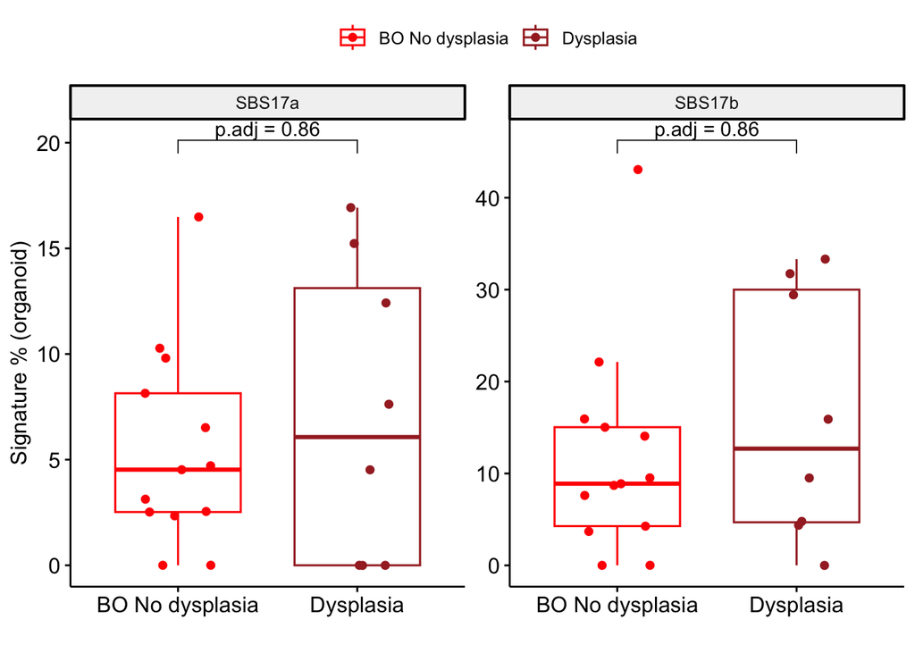

```r
# Finally, just compare Sig17 across the Barrett's PDOs
sigs.extracted_complete %>%
  dplyr::select(`Patient ID`, `Organoid or Tissue`, SBS17a, SBS17b) %>%
  mutate(Stage = factor(sapply(`Patient ID`, function(x)
    strsplit(x,split='_')[[1]][2]),
    levels = c('BO No dysplasia','Dysplasia'))) %>%
  filter(!is.na(Stage) & `Organoid or Tissue` == 'Organoids') %>%
  pivot_longer(cols = c(SBS17a, SBS17b), names_to = 'Signature', values_to = 'Proportion') %>%
  mutate(Proportion = 100 * Proportion) %>%
  group_by(Signature) %>%
  wilcox_test(Proportion ~ Stage) %>%
  adjust_pvalue(method = 'BH') %>% add_significance('p.adj') %>%
  add_xy_position(x = 'Stage') %>%
  mutate(p.adj_label = sapply(p.adj, function(x) paste0('p.adj = ',round(x,2)))) -> stat_sig17.test_byStage

sigs.extracted_complete %>%
  dplyr::select(`Patient ID`, `Organoid or Tissue`, SBS17a, SBS17b) %>%
  mutate(Stage = factor(sapply(`Patient ID`, function(x)
    strsplit(x,split='_')[[1]][2]),
    levels = c('BO No dysplasia','Dysplasia'))) %>%
  filter(!is.na(Stage) & `Organoid or Tissue` == 'Organoids') %>%
  pivot_longer(cols = c(SBS17a, SBS17b), names_to = 'Signature', values_to = 'Proportion') %>%
  mutate(Proportion = 100 * Proportion) %>%
  ggboxplot(x = 'Stage', y = 'Proportion', add = 'jitter', color = 'Stage') +
  theme(legend.title = element_blank()) +
  labs(x = '', y = 'Signature % (organoid)') +
  scale_color_manual(values = c('red1','brown')) +
  stat_pvalue_manual(stat_sig17.test_byStage, label = 'p.adj_label') +
  facet_wrap(~Signature, scales = 'free')
```

```r
ggsave(filename = 'Results/OrganoidsGastricBO_organoidsSignature17_byStage.pdf', height = 5)
```

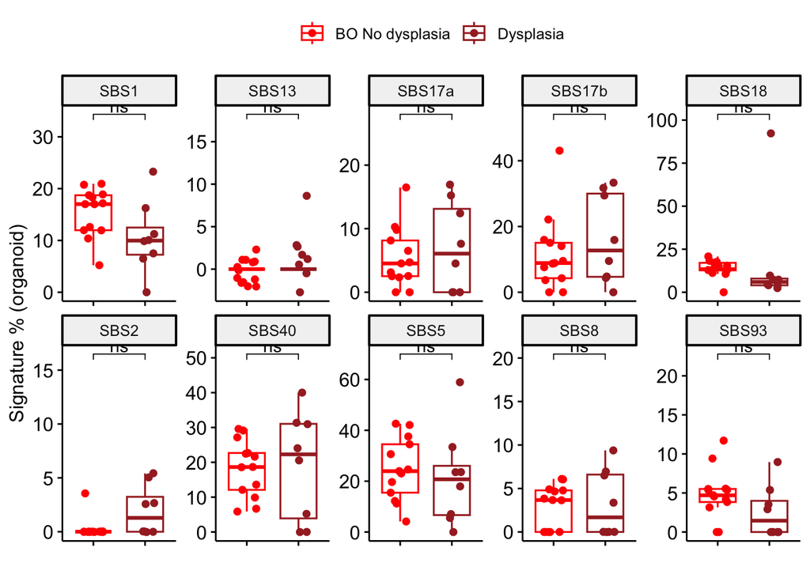

```r
# Save total Signature 17 contribition
df.sig17 <- data.frame(
  sequence_id = sigs.extracted_complete$sequence_id,
  `Patient ID` = sigs.extracted_complete$`Patient ID`,
  `Organoid or Tissue` = sigs.extracted_complete$`Organoid or Tissue`,
  SBS17 = sigs.extracted_complete$SBS17a + sigs.extracted_complete$SBS17b
)

# # For curiosity's sake, plot SBS17 proportion across groups
# df.sig17_plot <- df.sig17 %>% filter(`Organoid.or.Tissue` == 'Organoids')
# df.sig17_plot$Group <- factor(sapply(df.sig17_plot$Patient.ID, function(x) strsplit(x,split='_')[[1]][2]),
#                               levels = c('Normal (Healthy)','Normal (Patient)','BO No dysplasia','Dysplasia'))
# ggboxplot(df.sig17_plot, x = 'Group', y = 'SBS17', add = 'jitter', color = 'Group') +
#   theme(legend.title = element_blank(), axis.text.x = element_blank()) +
#   scale_color_manual(values = c('red1','brown')) +
#   labs(x = '', y = 'Signature 17')
# ggsave(filename = 'Results/OrganoidsGastricBO_Signature17byStatus.pdf', height = 5)

# We can also repeat this analysis right across all signatures
sigs.extracted_complete %>%
  dplyr::select(-c(`sequence_id`,`SBS_unknown`)) %>%
  mutate(Stage = factor(sapply(`Patient ID`, function(x)
    strsplit(x,split='_')[[1]][2]),
    levels = c('BO No dysplasia','Dysplasia'))) %>%
  filter(!is.na(Stage) & `Organoid or Tissue` == 'Organoids') %>%
  pivot_longer(cols = -c(`Patient ID`,`Organoid or Tissue`, `Stage`), names_to = 'Signature', values_to = 'Proportion') %>%
  mutate(Proportion = 100 * Proportion) %>%
  group_by(Signature) %>%
  wilcox_test(Proportion ~ Stage) %>%
  adjust_pvalue(method = 'BH') %>% add_significance('p.adj') %>%
  add_xy_position(x = 'Stage') %>%
  mutate(p.adj_label = sapply(p.adj, function(x) paste0('p.adj = ',round(x,2)))) -> stat_allSigs.test_byStage

sigs.extracted_complete %>%
  dplyr::select(-c(`sequence_id`,`SBS_unknown`)) %>%
  mutate(Stage = factor(sapply(`Patient ID`, function(x)
    strsplit(x,split='_')[[1]][2]),
    levels = c('BO No dysplasia','Dysplasia'))) %>%
  filter(!is.na(Stage) & `Organoid or Tissue` == 'Organoids') %>%
  pivot_longer(cols = -c(`Patient ID`,`Organoid or Tissue`, `Stage`), names_to = 'Signature', values_to = 'Proportion') %>%
  mutate(Proportion = 100 * Proportion) %>%
  ggboxplot(x = 'Stage', y = 'Proportion', add = 'jitter', color = 'Stage') +
  theme(legend.title = element_blank(), axis.text.x = element_blank()) +
  labs(x = '', y = 'Signature % (organoid)') +
  scale_color_manual(values = c('red1','brown')) +
  stat_pvalue_manual(stat_allSigs.test_byStage, label = 'p.adj.signif') +
  facet_wrap(~Signature, scales = 'free', nrow=2)
```

```r
ggsave(filename = 'Results/OrganoidsGastricBO_organoidsAllSignatures_byStage.pdf', height = 5)
write.csv(sigs.extracted_complete, file = 'Results/OrganoidsGastricBO_SignatureContributions.csv')
```

# 3 Oncoplot

Collate oncoplot

## 3.1 Prepare driver data

Note that a large number of samples (primarily normal gastric organoids) do not harbour any driver mutations, and so these must be added to the matrix manually.

```r
# Group by sequence_id+Gene to generate a single 'mutationLabel', with mutations separated by ';'
muts.oac_plot <- muts.oac %>%
  group_by(`Patient ID`, sequence_id, `Organoid or Tissue`, Gene, mutationType) %>%
  summarise() %>%
  group_by(`Patient ID`, sequence_id, `Organoid or Tissue`, Gene) %>%
  summarise(mutationLabel = paste(mutationType, collapse=';')) %>%
  mutate(mutationLabel = paste0(mutationLabel,';'))
```

```
## `summarise()` has regrouped the output.
## `summarise()` has regrouped the output.
## ℹ Summaries were computed grouped by Patient ID, sequence_id, Organoid or
##   Tissue, Gene, and mutationType.
## ℹ Output is grouped by Patient ID, sequence_id, Organoid or Tissue, and Gene.
## ℹ Use `summarise(.groups = "drop_last")` to silence this message.
## ℹ Use `summarise(.by = c(Patient ID, sequence_id, Organoid or Tissue, Gene,
##   mutationType))` for per-operation grouping (`?dplyr::dplyr_by`) instead.
```

```r
# Pivot alterations out to generate a matrix
muts.oac_plot <- muts.oac_plot[,c('sequence_id','Gene','mutationLabel')] %>%
  pivot_wider(names_from = sequence_id, values_from = mutationLabel) %>%
  column_to_rownames(var = 'Gene') %>% as.matrix
muts.oac_plot[is.na(muts.oac_plot)] <- ''

# Add 17 samples without driver mutations
sequence_id.no_drivers <- unique(vep.files_sequenceID[!(vep.files_sequenceID %in% colnames(muts.oac_plot))])
mat.no_drivers <- matrix(data = '', nrow=nrow(muts.oac_plot), ncol=length(sequence_id.no_drivers))
colnames(mat.no_drivers) <- sequence_id.no_drivers; rownames(mat.no_drivers) <- rownames(muts.oac_plot)

muts.oac_plot <- cbind(muts.oac_plot, mat.no_drivers)
```

## 3.2 Prepare annotation information

Here, we will collate the genomic features we have profiled previously (TMB, ploidy/purity, HRD index score, signatures), as well as clinical metadata.

```r
# Collate genomic features we have collected here. Note that for the Birmingham organoids we are restricted to TMB and ploidy
muts.oac_ann <- df.ascatAnno[,c('sequence_id','Patient ID','Organoid or Tissue','Passage','Ploidy','Purity')] # start with ploidy/purity
muts.oac_ann <- merge(x = muts.oac_ann, y = df.tmb, all.x = TRUE) # add TMB
muts.oac_ann <- merge(x = muts.oac_ann, y = df.scarHRD[,c('sequence_id','Patient ID','Organoid or Tissue','HRD-sum')], all.x = TRUE) # add HRD index score
muts.oac_ann <- merge(x = muts.oac_ann, y = df.sig17, all.x = TRUE) # add SBS17

# Add SBS18 and SBS40 - this will be for the summary plot
muts.oac_ann <- merge(x = muts.oac_ann, y = sigs.extracted_complete[,c('sequence_id','SBS18','SBS40')], all.x = TRUE)

# Now we can add relevant clinical information
#   Note that we will have to add the Birmingham organoids, and the AHM OAC organoids, manually
meta.clin <- meta %>%
  dplyr::select(index_corrected, Sex, Age, `Type/site`, `Tissue/Organoid Grade`, HighestGrade)

muts.oac_ann <- merge(x = muts.oac_ann, y = meta.clin, all.x = TRUE,
                      by.x = 'sequence_id', by.y = 'index_corrected')

# Fix up annotation data, and reorder by stage, case ID, and specimen source for plotting
#
muts.oac_ann$Age <- as.numeric(muts.oac_ann$Age)
muts.oac_ann$`Tissue/Organoid Grade` <- factor(muts.oac_ann$`Tissue/Organoid Grade`,
                                               levels = c('Normal (Healthy)','Normal (Patient)',
                                                          'BO No dysplasia','Dysplasia'))
muts.oac_ann$HighestGrade <- factor(muts.oac_ann$HighestGrade,
                                    levels = c('Normal donor','BO No dysplasia','LGD',
                                               'OAC','Gastric cancer'))

muts.oac_ann$Passage <- sapply(muts.oac_ann$Passage, function(x) as.numeric(str_replace(x,'P','')))
muts.oac_ann <- muts.oac_ann %>% arrange(`Tissue/Organoid Grade`, `Patient ID`, desc(`Organoid or Tissue`))

# Reorder oncoplot data to reflect annotation shown here
muts.oac_plot <- muts.oac_plot[,muts.oac_ann$sequence_id]
```

Here, we can add in a couple of driver mutations which were, most likely erroneously, filtered out during variant calling. These are cases where the mutation is present fully in either the organoid or the tissue, and where it was called but filtered in the other.

```r
strelka_check <- read.table('Data/strelka_check_fullBO_allfs.txt')
strelka_check <- strelka_check %>%
  filter(!is.na(Tissue_unfiltered) & !is.na(Organoids_unfiltered)) %>%
  filter((Tissue_unfiltered == 'PASS' & Organoids_unfiltered != 'PASS') |
           (Tissue_unfiltered != 'PASS' & Organoids_unfiltered == 'PASS'))
strelka_check
```

```
##         mutationID         sequenceID_organoid           sequenceID_tissue
## 26 13_58299162_T/C         SLX-18949.i710_i517         SLX-18949.i705_i506
## 28 16_72991727_G/A SLX-21369_SLX-26253.UDP0006 SLX-21369_SLX-26253.UDP0059
## 33  17_7577548_C/T SLX-21369_SLX-26253.UDP0033 SLX-21369_SLX-26253.UDP0058
## 52 5_112175639_C/T SLX-21369_SLX-26253.UDP0025 SLX-21369_SLX-26253.UDP0036
## 65  8_11566168_C/T         SLX-18949.i707_i503         SLX-18949.i714_i517
##                 Patient.ID   Gene Tissue Organoids          Tissue_unfiltered
## 26       AHM2221_Dysplasia PCDH17      1         0                       PASS
## 28 AHM2149_BO No dysplasia  ZFHX3      1         0                       PASS
## 33 AHM2575_BO No dysplasia   TP53      0         1              SNVCluster100
## 52     AHM2165_Dysplasia_2    APC      0         1 SNVCluster100;SNVCluster50
## 65 AHN0070_BO No dysplasia  GATA4      1         0                       PASS
##          Organoids_unfiltered
## 26 SNVCluster100;SNVCluster50
## 28         VariantAlleleCount
## 33                       PASS
## 52                       PASS
## 65               SNVCluster50
```

```r
# Add mutations
muts.oac_plot['PCDH17','SLX-18949.i710_i517'] <- muts.oac_plot['PCDH17','SLX-18949.i705_i506']
muts.oac_plot['ZFHX3','SLX-21369_SLX-26253.UDP0006'] <- muts.oac_plot['ZFHX3','SLX-21369_SLX-26253.UDP0059']
muts.oac_plot['TP53','SLX-21369_SLX-26253.UDP0058'] <- muts.oac_plot['TP53','SLX-21369_SLX-26253.UDP0033']
muts.oac_plot['APC','SLX-21369_SLX-26253.UDP0036'] <- muts.oac_plot['APC','SLX-21369_SLX-26253.UDP0025']
muts.oac_plot['GATA4','SLX-18949.i707_i503'] <- muts.oac_plot['GATA4','SLX-18949.i714_i517']
```

## 3.3 Define plotting features for oncoPrint

```r
col.bars = c("Amplification" = "darkred", "Deletion" = "turquoise3",
        'frameshift_variant' = 'blue3', 'inframe_deletion' = 'orange3',
        'missense_variant' = 'red2', 'NMD_transcript_variant' = 'darkgreen', 'stop_gained' = 'purple3')

alter_fun = list(
  background = alter_graphic("rect", fill = "gray90"),
  Amplification = alter_graphic("rect", fill = col.bars["Amplification"]),
  Deletion = alter_graphic("rect", fill = col.bars["Deletion"]),
  # Loss = alter_graphic("rect", fill = col.bars["Loss"]),
  frameshift_variant = alter_graphic("rect", height = 0.33, fill = col.bars["frameshift_variant"]),
  inframe_deletion = alter_graphic("rect", height = 0.33, fill = col.bars["inframe_deletion"]),
  missense_variant = alter_graphic("rect", height = 0.33, fill = col.bars["missense_variant"]),
  NMD_transcript_variant = alter_graphic("rect", height = 0.33, fill = col.bars["NMD_transcript_variant"]),
  stop_gained = alter_graphic("rect", height = 0.33, fill = col.bars["stop_gained"])
)
```

This can also include barplots to go on the right-hand annotation, which will be separated between organoids and tissues

```r
# Generate barplot of driver genes in tissues, which should include all possible driver genes and driver events
annoMut.tissue_init <- muts.oac %>%
  filter(`Organoid or Tissue` == 'Tissue') %>%
  group_by(Gene, mutationType) %>% summarise(n = length(unique(sequence_id))) %>%
  pivot_wider(names_from = 'mutationType', values_from = n, values_fill = 0) %>%
  column_to_rownames(var = 'Gene') %>% as.matrix
```

```
## `summarise()` has regrouped the output.
## ℹ Summaries were computed grouped by Gene and mutationType.
## ℹ Output is grouped by Gene.
## ℹ Use `summarise(.groups = "drop_last")` to silence this message.
## ℹ Use `summarise(.by = c(Gene, mutationType))` for per-operation grouping
##   (`?dplyr::dplyr_by`) instead.
```

```r
annoMut.tissue <- rbind(annoMut.tissue_init,
                        matrix(0,nrow=nrow(muts.oac_plot)-nrow(annoMut.tissue_init),
                               ncol=ncol(annoMut.tissue_init)))
rownames(annoMut.tissue)[(nrow(annoMut.tissue_init)+1):nrow(muts.oac_plot)] <-
  unique(muts.oac$Gene)[!(unique(muts.oac$Gene) %in% rownames(annoMut.tissue))]

annoMut.tissue <- annoMut.tissue[,names(col.bars)]
annoMut.tissue <- annoMut.tissue[rownames(muts.oac_plot), ]

# Generate barplot of driver genes in organoids, which should include all possible driver genes and driver events
annoMut.organoid_init <- muts.oac %>%
  filter(`Organoid or Tissue` == 'Organoids') %>%
  group_by(Gene, mutationType) %>% summarise(n = length(unique(sequence_id))) %>%
  pivot_wider(names_from = 'mutationType', values_from = n, values_fill = 0) %>%
  column_to_rownames(var = 'Gene') %>% as.matrix
```

```
## `summarise()` has regrouped the output.
## ℹ Summaries were computed grouped by Gene and mutationType.
## ℹ Output is grouped by Gene.
## ℹ Use `summarise(.groups = "drop_last")` to silence this message.
## ℹ Use `summarise(.by = c(Gene, mutationType))` for per-operation grouping
##   (`?dplyr::dplyr_by`) instead.
```

```r
annoMut.organoid <- rbind(annoMut.organoid_init,
                          matrix(0,nrow=nrow(muts.oac_plot)-nrow(annoMut.organoid_init),
                                 ncol=ncol(annoMut.organoid_init)))
rownames(annoMut.organoid)[(nrow(annoMut.organoid_init)+1):nrow(muts.oac_plot)] <-
  unique(muts.oac$Gene)[!(unique(muts.oac$Gene) %in% rownames(annoMut.organoid))]

annoMut.organoid <- annoMut.organoid[,names(col.bars)]
annoMut.organoid <- annoMut.organoid[rownames(muts.oac_plot), ]
```

And with that, we should be able to collate the final oncoplot…

```r
heatmap_legend_param = list(title = "Alterations", at = names(col), labels = names(col))

# Alter column names, for ease of reading. This involves 'OCCAMS/AH', being replace with 'CAM', and clarification of organoid or tumour
muts.oac_ann$column_name <- muts.oac_ann$`Patient ID`
muts.oac_ann$column_name <- apply(muts.oac_ann, 1, function(x)
  paste(x['column_name'],substr(x['Organoid or Tissue'],1,1),sep='_'))

colnames(muts.oac_plot) <- muts.oac_ann$column_name

# Final oncoprint formation
pdf('Results/Oncoplot_GastricBEtissuesOrganoids.pdf', width = 16, height = 12)
oncoPrint(muts.oac_plot,
          alter_fun = alter_fun, col = col.bars,
          column_split = data.frame(muts.oac_ann$`Tissue/Organoid Grade`, muts.oac_ann$`Patient ID`),
          top_annotation = HeatmapAnnotation(
            cbar = anno_oncoprint_barplot(),
            Purity = anno_points(muts.oac_ann$Purity),
            Ploidy = anno_points(muts.oac_ann$Ploidy),
            `TMB (muts/Mb)` = anno_barplot(muts.oac_ann$TMB, bar_width = .8, gp = gpar(fill = 'purple4')),
            `Signature 17` = muts.oac_ann$SBS17,
            `Age` = muts.oac_ann$Age,
            # `HRD score` = anno_simple(muts.oac_ann$`HRD-sum`,
            #                           col = colorRamp2(c(0,max(muts.oac_ann$`HRD-sum`, na.rm = TRUE)),
            #                                            colors = c('white','pink3'))),
            `Sex` = muts.oac_ann$Sex,
            `Site` = muts.oac_ann$`Type/site`,
            Passage = muts.oac_ann$Passage,
            `Highest Grade` = muts.oac_ann$HighestGrade,
            `Grade` = muts.oac_ann$`Tissue/Organoid Grade`,
            `Tissue/Organoid` = muts.oac_ann$`Organoid or Tissue`,
            col = list(cbar = col.bars,
                       `Tissue/Organoid` = c('Tissue'='gray20','Organoids'='gray90'),
                       `Sex` = c('M' = 'darkblue', 'F' = 'lightblue'),
                       `Grade` = c('Normal (Healthy)' = 'yellow2', 'Normal (Patient)' = 'orange',
                                   'BO No dysplasia' = 'red1', 'Dysplasia' = 'brown'),
                       `Site` = c('Esophagus' = 'pink',
                                  'Gastric antrum' = 'sienna1', 'Gastric body' = 'coral1',
                                  'Gastric cardia' = 'sienna3', 'GOJ' = 'coral4'),
                       `Highest Grade` = c('Normal donor' = 'mistyrose',
                                           'BO No dysplasia' = 'plum2', 'LGD' = 'plum3',
                                           'OAC' = 'purple3', 'Gastric cancer' = 'mediumorchid4'),
                       `Signature 17` = colorRamp2(c(0,max(muts.oac_ann$SBS17, na.rm = TRUE)),colors = c('white','green4')),
                       Passage = colorRamp2(c(1,max(muts.oac_ann$Passage, na.rm=TRUE)), colors = c('darkslategray1','darkslategray4')),
                       `Age` = colorRamp2(c(30,max(muts.oac_ann$Age, na.rm = TRUE)),colors=c('white','gold3'))),
            na_col = 'gray75'
          ),
          right_annotation = rowAnnotation(
            Tissue = anno_barplot(annoMut.tissue, gp=gpar(fill = col.bars)),
            Organoid = anno_barplot(annoMut.organoid, gp=gpar(fill = col.bars))
          ),
          heatmap_legend_param = heatmap_legend_param,
          column_order = colnames(muts.oac_plot),
          show_column_names = TRUE,
          show_pct = FALSE)
```

```
## All mutation types: frameshift_variant, stop_gained, Deletion,
## NMD_transcript_variant, missense_variant, inframe_deletion,
## Amplification.
```

```
## `alter_fun` is assumed vectorizable. If it does not generate correct
## plot, please set `alter_fun_is_vectorized = FALSE` in `oncoPrint()`.
```

```r
dev.off()
```

```r
# Save annotation
write.csv(muts.oac_ann, file = 'Results/Oncoplot_GastricBE_annotation.csv')
write.csv(muts.oac, file = 'Results/OrganoidsGastricBO_OACcodingAlterations.csv')
```

We should also use these complete annotation files to confirm average TMBs across organoids and tissues from BE.

```r
# Across all BE
muts.oac_ann %>%
  filter(`Tissue/Organoid Grade` %in% c('BO No dysplasia','Dysplasia')) %>%
  group_by(`Organoid or Tissue`) %>%
  summarise(medianTMB = median(TMB), meanTMB = mean(TMB))
```

```
## # A tibble: 2 × 3
##   `Organoid or Tissue` medianTMB meanTMB
##   <chr>                    <dbl>   <dbl>
## 1 Organoids                 3.70    3.59
## 2 Tissue                    2.92    3.40
```

```r
# Separate BE into NDBE and dysplasia
muts.oac_ann %>%
  filter(`Tissue/Organoid Grade` %in% c('BO No dysplasia','Dysplasia')) %>%
  group_by(`Tissue/Organoid Grade`, `Organoid or Tissue`) %>%
  summarise(medianTMB = median(TMB), meanTMB = mean(TMB))
```

```
## `summarise()` has regrouped the output.
## ℹ Summaries were computed grouped by Tissue/Organoid Grade and Organoid or
##   Tissue.
## ℹ Output is grouped by Tissue/Organoid Grade.
## ℹ Use `summarise(.groups = "drop_last")` to silence this message.
## ℹ Use `summarise(.by = c(Tissue/Organoid Grade, Organoid or Tissue))` for
##   per-operation grouping (`?dplyr::dplyr_by`) instead.
```

```
## # A tibble: 4 × 4
## # Groups:   Tissue/Organoid Grade [2]
##   `Tissue/Organoid Grade` `Organoid or Tissue` medianTMB meanTMB
##   <fct>                   <chr>                    <dbl>   <dbl>
## 1 BO No dysplasia         Organoids                 2.11    2.66
## 2 BO No dysplasia         Tissue                    1.89    2.61
## 3 Dysplasia               Organoids                 5.76    5.10
## 4 Dysplasia               Tissue                    4.57    4.59
```

# 4 Concordance Analysis

The final step of this analysis is to demonstrate the level of concordance in mutation profiles between matched organoid/tissue pairs. This will be done using the full set of SNVs and indels contained within the ‘vcfs.all’ object used to calculate the mutational signatures. And since the variant allele frequencies were also saved, we can check how this is altered in organoids compared with tissues.

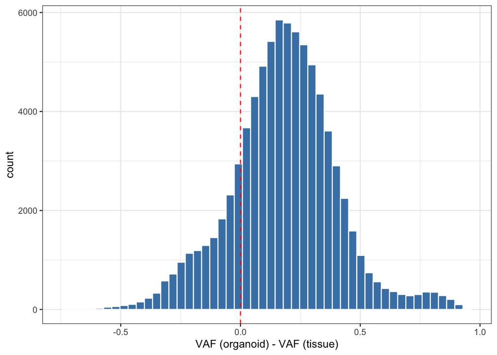

```r
# Add metadata
vcfs.full <- merge(x = vcfs.all, y = meta[,c('index_corrected','Patient ID','Organoid or Tissue','Passage')],
                   by.x = 'sequence_id', by.y = 'index_corrected')

# This will only be relevant to SNVs, so we extract these
vcfs.full <- vcfs.full %>%
  filter(REF %in% c('A','C','T','G') &
           ALT %in% c('A','C','T','G'))

# Paired mutations can be identified via a specific mutationID containing case ID and mutation information, which is then pivoted out to compare VAFs
vcfs.full$POS <- as.character(vcfs.full$POS)
vcfs.full$MUTATION_ID <- apply(vcfs.full[,c(8,2:5)], 1, function(x) paste(x,collapse='_'))

vcfs.shared <- vcfs.full %>%
  dplyr::select(MUTATION_ID, `Organoid or Tissue`, VAF) %>%
  pivot_wider(names_from = `Organoid or Tissue`, values_from = VAF) %>%
  mutate(VAF_diff = Organoids - Tissue)
ggplot(vcfs.shared, aes(x = VAF_diff)) + theme_bw() +
  geom_histogram(bins = 50, fill = 'steelblue', color = 'white') +
  geom_vline(col = 'red', linetype = 'dashed', xintercept = 0) +
  xlab('VAF (organoid) - VAF (tissue)')
```

```r
ggsave(filename = 'Results/OrganoidsGastricBO_differencesVAF.pdf', height = 5, width = 5)
# Label mutations as Concordant, Organoid_only, or Tissue_only, add case_id and summarise counts of each
vcfs.shared$Label <- 'Concordant'
vcfs.shared$Label[is.na(vcfs.shared$Tissue)] <- 'Organoid_only'
vcfs.shared$Label[is.na(vcfs.shared$Organoids)] <- 'Tissue_only'

vcfs.shared$case_id <- sapply(vcfs.shared$MUTATION_ID, function(x)
  paste(strsplit(x,split='_')[[1]][1:2],collapse='_'))

muts.shared_summary <- vcfs.shared %>%
  group_by(case_id, Label) %>% summarise(n=n())
```

```
## `summarise()` has regrouped the output.
## ℹ Summaries were computed grouped by case_id and Label.
## ℹ Output is grouped by case_id.
## ℹ Use `summarise(.groups = "drop_last")` to silence this message.
## ℹ Use `summarise(.by = c(case_id, Label))` for per-operation grouping
##   (`?dplyr::dplyr_by`) instead.
```

```r
# Rank case_id by percentage of concordant mutations, and remove samples with no matched tissue
muts.concordant <-muts.shared_summary %>%
  pivot_wider(names_from = Label, values_from = n, values_fill = 0) %>%
  mutate(percentage_Concordant = Concordant/(Concordant + Organoid_only + Tissue_only)) %>%
  arrange(percentage_Concordant) %>%
  filter(percentage_Concordant > 0)

summary(muts.concordant$percentage_Concordant)
```

```
##    Min. 1st Qu.  Median    Mean 3rd Qu.    Max.
## 0.00269 0.11220 0.23759 0.25777 0.37450 0.65346
```

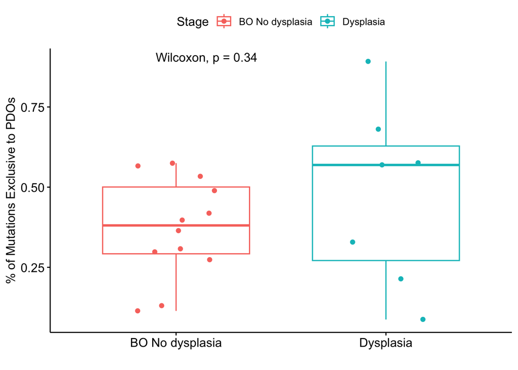

```r
muts.concordant$percentage_Organoid <- muts.concordant$Organoid_only/apply(muts.concordant[,2:4], 1, sum)
muts.concordant$Stage <- factor(sapply(as.character(muts.concordant$case_id),
                                       function(x) strsplit(x,split='_')[[1]][2]),
                                levels = c('BO No dysplasia', 'Dysplasia'))
ggboxplot(muts.concordant, x = 'Stage', y = 'percentage_Organoid', add = 'jitter', color = 'Stage') +
  stat_compare_means() +
  labs(x = '', y = '% of Mutations Exclusive to PDOs')
```

```r
muts.concordant %>% group_by(Stage) %>% summarise(median_ExclusivePDO = 100*median(percentage_Organoid))
```

```
## # A tibble: 2 × 2
##   Stage           median_ExclusivePDO
##   <fct>                         <dbl>
## 1 BO No dysplasia                38.1
## 2 Dysplasia                      56.9
```

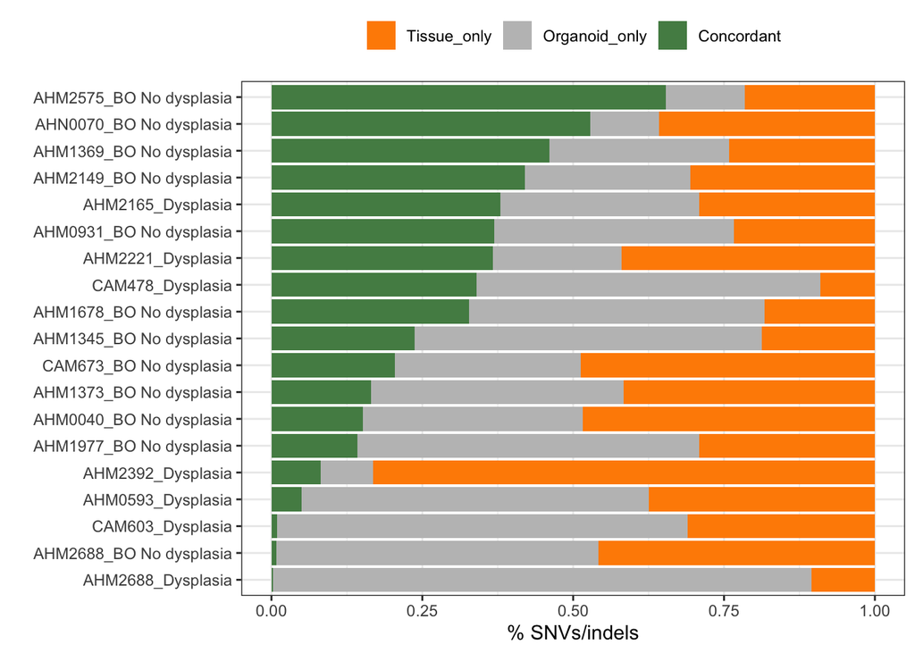

```r
# Remove samples with no matched tissues
muts.shared_summary <- muts.shared_summary %>%
  filter(case_id %in% muts.concordant$case_id) %>%
  mutate(case_id = factor(case_id, levels=muts.concordant$case_id),
         Label = factor(Label, levels = c('Tissue_only','Organoid_only','Concordant')))

ggplot(muts.shared_summary, aes(x = n, y = case_id, fill = Label)) +
  scale_fill_manual(values = c('darkorange','gray75','palegreen4')) +
  geom_bar(stat = 'identity', position = 'fill') +
  theme_bw() + theme(legend.position = 'top',
                     legend.title = element_blank()) +
  labs(x = '% SNVs/indels', y = '')
```

```r
ggsave(filename = 'Results/OrganoidsGastricBO_concordanceWGS.pdf', height = 5)
```

However, could it be that the sample purity is what drives the concordance, or lack thereof?

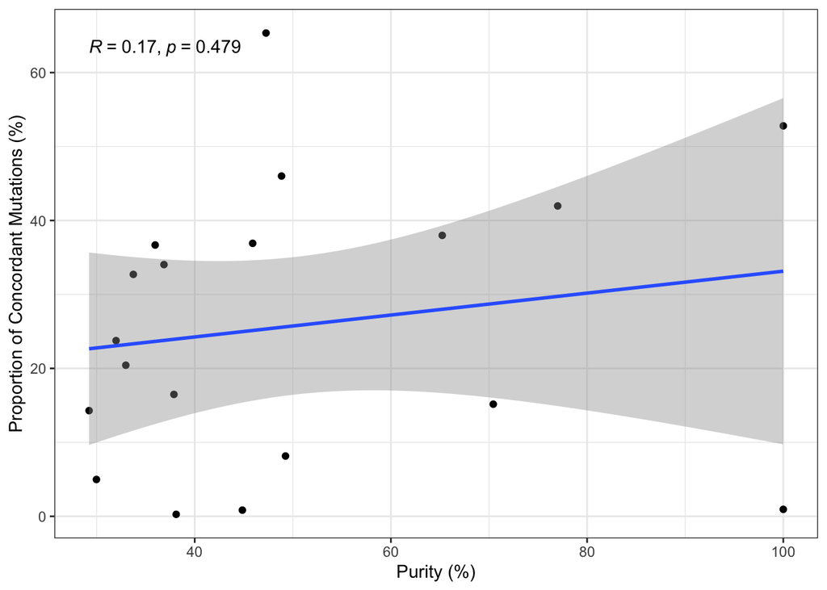

```r
muts.concordant_purity <- merge(x = muts.concordant[,c('case_id','percentage_Concordant')],
                                y = muts.oac_ann[muts.oac_ann$`Organoid or Tissue` == 'Tissue',c('Patient ID','Purity','Tissue/Organoid Grade')],
                                by.x = 'case_id', by.y = 'Patient ID')

ggplot(muts.concordant_purity, aes(x = 100*Purity, y = 100*percentage_Concordant)) +
  theme_bw() +
  geom_point() + geom_smooth(method = 'lm') + stat_cor(p.accuracy=.001) +
  labs(x = 'Purity (%)', y = 'Proportion of Concordant Mutations (%)')
```

We can also check if PDO passage is linked with VAF distributions, as we investigate further with AHM/1373

```r
# Subset all SNVs for those in PDOs specifically
vcfs.full_pdos <- vcfs.full %>% dplyr::filter(`Organoid or Tissue` == 'Organoids')
vcfs.full_pdos$Label <- apply(vcfs.full_pdos, 1, function(x) paste(x[c('Patient ID','Passage')], collapse='_'))
vcfs.full_pdos$Grade <- sapply(vcfs.full_pdos$`Patient ID`, function(x) strsplit(x,split='_')[[1]][2])

# Order 'Patient ID' by grade and increasing passage
vcfs.full_pdos_patient_passage <- vcfs.full_pdos %>%
  group_by(`Patient ID`, Passage) %>% summarise() %>%
  mutate(Grade = factor(sapply(`Patient ID`, function(x) strsplit(x,split='_')[[1]][2]),
                        levels = c('Normal (Healthy)','Normal (Patient)','BO No dysplasia','Dysplasia')))
```

```
## `summarise()` has regrouped the output.
## ℹ Summaries were computed grouped by Patient ID and Passage.
## ℹ Output is grouped by Patient ID.
## ℹ Use `summarise(.groups = "drop_last")` to silence this message.
## ℹ Use `summarise(.by = c(Patient ID, Passage))` for per-operation grouping
##   (`?dplyr::dplyr_by`) instead.
```

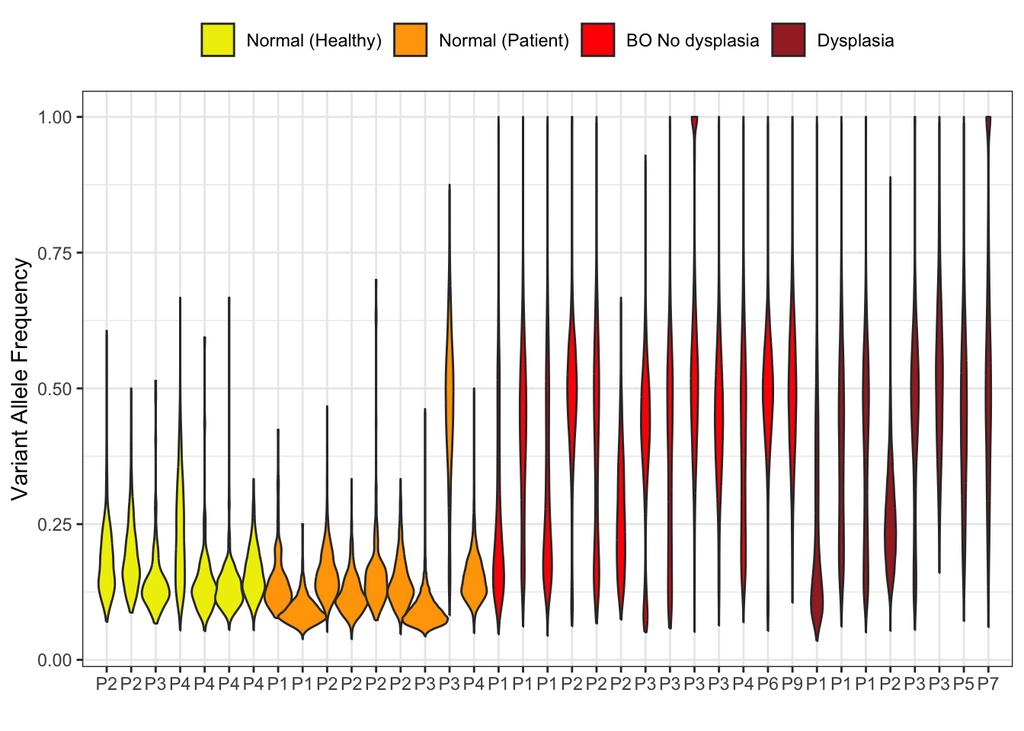

```r
vcfs.full_pdos_patient_passage$Label <- apply(vcfs.full_pdos_patient_passage, 1, function(x) paste(x[c('Patient ID','Passage')], collapse='_'))
vcfs.full_pdos_patient_passage <- vcfs.full_pdos_patient_passage %>% arrange(Grade, Passage)

# Convert Label into a factor, and plot VAF distributions as violins
vcfs.full_pdos$Label <- factor(vcfs.full_pdos$Label, levels = vcfs.full_pdos_patient_passage$Label)
vcfs.full_pdos$Grade <- factor(vcfs.full_pdos$Grade, levels = c('Normal (Healthy)','Normal (Patient)','BO No dysplasia','Dysplasia'))

ggplot(vcfs.full_pdos, aes(x = Label, y = VAF, fill = Grade)) + theme_bw() +
  geom_violin(width = 2) + theme(legend.title = element_blank(), legend.position = 'top') +
  labs(x = '',y = 'Variant Allele Frequency') +
  scale_fill_manual(values = c('yellow2','orange','red1','brown')) +
  scale_x_discrete(labels = vcfs.full_pdos_patient_passage$Passage)
```

[output not shown]

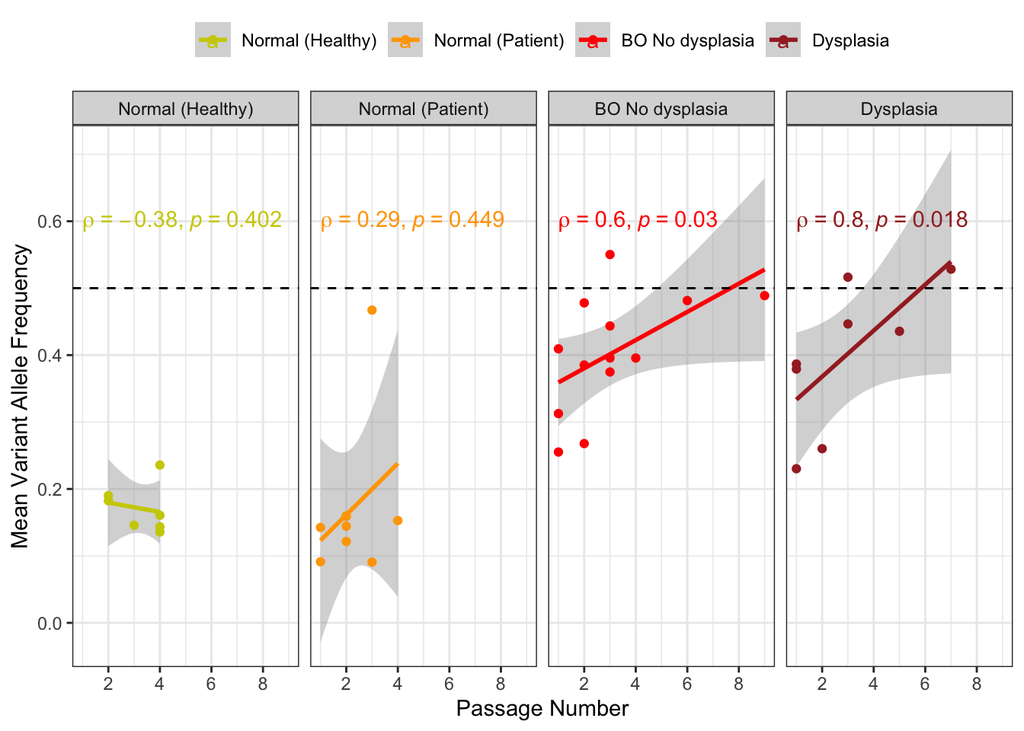

```r
# And numerically compare passage with mean VAF
vcfs.full_pdos %>%
  group_by(Grade, Label, Passage) %>% summarise(mean_VAF = mean(VAF), median_VAF = median(VAF)) %>%
  mutate(Passage_Number = as.numeric(str_replace(Passage,'P',''))) %>%
  ggplot(aes(x = Passage_Number, y = mean_VAF, color = Grade)) + theme_bw() +
  geom_smooth(method = 'lm') +
  geom_point() + theme(legend.position = 'top', legend.title = element_blank()) +
  scale_color_manual(values = c('yellow3','orange','red1','brown')) +
  labs(x = 'Passage Number', y = 'Mean Variant Allele Frequency') +
  geom_hline(col = 'black', linetype = 'dashed', yintercept = 0.5) +
  scale_x_continuous(breaks = seq(0,8,2)) +
  stat_cor(method = 'spearman', label.y = .6, p.accuracy = .001, cor.coef.name = 'rho') +
  facet_wrap(~Grade, nrow=1)
```

# 5 Clonality Analysis

For one Barrett’s organoid (AHM/1373), we have WGS from the organoid at passages 1 and 6. Consequently, we can compare them to identify any clonal dynamics that may have occurred.

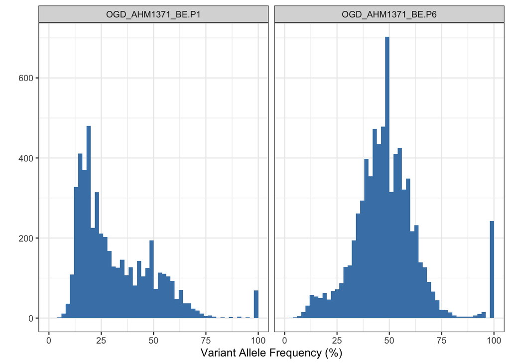

```r
# Load data
files.vcf_ahm1373 <- list.files(path = 'Data/WGS_AHM1373_ClonalDynamics/strelka',
                                full.names = TRUE, recursive = TRUE, pattern = '.snp.pass.vcf$')

snvs_ahm1373.all <- data.frame()
for (file in files.vcf_ahm1373) {

  # read VCF files
  vcf.i <- read.vcfR(file, verbose = FALSE)@fix %>% as.data.frame

  # Label sample by P1 or P6
  vcf.i$SAMPLE_ID <- ifelse(grepl(pattern = 'UDP0018',file), 'OGD_AHM1371_BE.P1', 'OGD_AHM1371_BE.P6')

  # Generate MUTATION_ID and save depth and VAF values
  vcf.i$MUTATION_ID <- apply(vcf.i, 1, function(x) paste(x[c(1,2,4,5)], collapse='_'))
  vcf.i$DEPTH <- sapply(vcf.i$INFO, function(x)
    as.numeric(strsplit(strsplit(x,split=';')[[1]][1],split='=')[[1]][2]))
  vcf.i$VAF <- sapply(vcf.i$INFO, function(x)
    as.numeric(strsplit(strsplit(x,split=';')[[1]][28],split='=')[[1]][2]))

  # Save SNVs
  snvs_ahm1373.all <- rbind(snvs_ahm1373.all, vcf.i[,-8])

}

ggplot(snvs_ahm1373.all, aes(x = 100*VAF)) + theme_bw() +
  geom_histogram(breaks = seq(0,100,by=2), fill = 'steelblue') +
  facet_wrap(~SAMPLE_ID) +
  labs(x = 'Variant Allele Frequency (%)', y = '')
```

```r
ggsave(filename = 'Results/AHM1373_VAFdistributions.pdf', height = 5)
```

Immediately, we can see that at the organoid at Passage 1 harbours subclonality, whereas by Passage 6 the organoid is essentially clonal. The question is, how many of the subclonal mutations at Passage 1 have developed clonality by Passage 6?

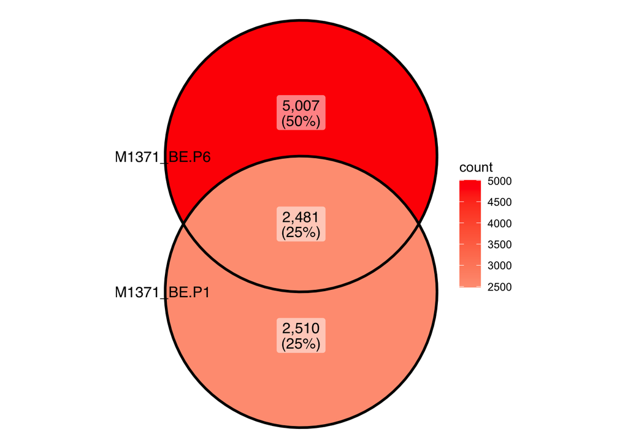

```r
# Initial Venn Diagram of shared SNVs
snvs_ahm1373.shared <- list(
  OGD_AHM1371_BE.P1 = snvs_ahm1373.all$MUTATION_ID[snvs_ahm1373.all$SAMPLE_ID == 'OGD_AHM1371_BE.P1'],
  OGD_AHM1371_BE.P6 = snvs_ahm1373.all$MUTATION_ID[snvs_ahm1373.all$SAMPLE_ID == 'OGD_AHM1371_BE.P6']
)
ggVennDiagram(snvs_ahm1373.shared) +
  scale_fill_gradient2(low = 'grey90', high = 'red', midpoint = 0)
```

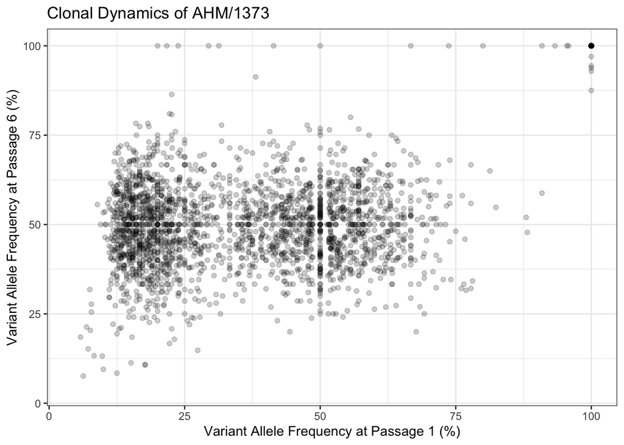

```r
# Now let's compare the VAFs of shared SNVs
#  (Note that currently only shared SNVs are shown, rather than those missing in one or the other)
muts.shared <- snvs_ahm1373.all %>%
  dplyr::select(MUTATION_ID, SAMPLE_ID, VAF) %>%
  pivot_wider(names_from = SAMPLE_ID, values_from = VAF, values_fill = NA)

ggplot(muts.shared, aes(x = 100*`OGD_AHM1371_BE.P1`, y = 100*`OGD_AHM1371_BE.P6`)) +
  theme_bw() + geom_point(alpha = .2) +
  labs(x = 'Variant Allele Frequency at Passage 1 (%)',
       y = 'Variant Allele Frequency at Passage 6 (%)') +
  ggtitle('Clonal Dynamics of AHM/1373')
```

```r
ggsave(filename = 'Results/AHM1373_ClonalDynamics.pdf',
       width = 7, height = 5)
```

# 6 Feature Comparison across Normal, Barrett’s, and Cancer Stages

## 6.1 Genomic features

As included in both of our heatmaps, we have collated information surrounding features which are specifically altered across stages of Barrett’s and tumour development. We can visualise these here, using the oncoplot annotation files we have generated.

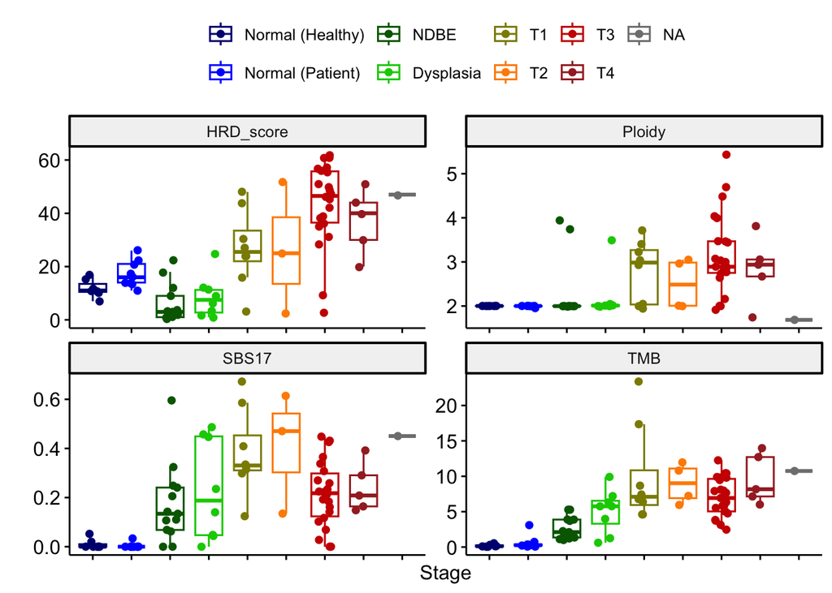

```r
# Fix Gastric/BO annotation and load OAC annotations
ann_bo <- muts.oac_ann
ann_oac <- read.csv('../OrganoidsOAC_WGS/Results/Oncoplot_OAC_annotation.csv', row.names = 1)

# Filter for organoids only and select/rename case_id, ploidy, TMB, HRD.sum, SBS17, Stage
ann_bo <- ann_bo %>%
  filter(`Organoid or Tissue` == 'Organoids') %>%
  dplyr::select(`Patient ID`, Ploidy, TMB, `HRD-sum`, SBS17, `Tissue/Organoid Grade`)
names(ann_bo) <- c('CaseID','Ploidy','TMB','HRD_score','SBS17','Stage')

ann_oac <- ann_oac %>%
  filter(specimen_source == 'organoid') %>%
  dplyr::select(case_id, Ploidy, TMB, `HRD.sum`, SBS17, Stage)
names(ann_oac) <- c('CaseID','Ploidy','TMB','HRD_score','SBS17','Stage')

# Fix stages, then join and factorise
ann_bo$Stage <- ann_bo$Stage %>% as.character
ann_bo$Stage[ann_bo$Stage == 'BO No dysplasia'] <- 'NDBE'

ann_oac$Stage <- ann_oac$Stage %>% as.character
ann_oac$Stage <- sapply(ann_oac$Stage, function(x) substr(x,1,2))

ann_full <- rbind(ann_bo, ann_oac)
ann_full$Stage <- factor(ann_full$Stage,
                         levels = c('Normal (Healthy)', 'Normal (Patient)','NDBE','Dysplasia',
                                    'T1','T2','T3','T4','Tx'))

# Plot features across all stages
ann_full <- ann_full %>%
  pivot_longer(cols = c(Ploidy,TMB,HRD_score,SBS17), names_to = 'Feature')



ggboxplot(ann_full, x = 'Stage', y = 'value', add = 'jitter', color = 'Stage') +
  theme(axis.text.x = element_blank(),
        legend.title = element_blank()) +
  labs(x = 'Stage', y = '') +
  scale_color_manual(values = c('navy','blue','darkgreen','green3',
                                'yellow4','darkorange','red3','brown','gray50')) +
  facet_wrap(~Feature, scales = 'free')
```

```r
ggsave(filename = 'Results/FullOrganoids_FeatureSet.pdf', height = 6, width = 9)
```

## 6.2 Driver alterations

We can also compare the driver gene profiles across our normal gastric, NDBE, dysplastic, and OAC organoids, which were saved in a previous scripts.

```r
# Load driver alterations in BO and OAC
drivers_bo <- muts.oac
drivers_bo$Group <- sapply(drivers_bo$`Patient ID`, function(x) strsplit(x,split='_')[[1]][2])
drivers_bo$Group[grepl(pattern = 'Normal', drivers_bo$Group)] <- 'Normal Gastric'
drivers_bo$Group[drivers_bo$Group == 'BO No dysplasia'] <- 'NDBE'

drivers_oac <- read.csv('../OrganoidsOAC_WGS/Results/OrganoidsOAC_OACcodingAlterations.csv', row.names = 1)
drivers_oac$Group <- 'OAC'

# Rename and reorder data frames for merging, and subset on organoids
names(drivers_oac) <- c('Patient ID', 'sequence_id','Gene','Organoid or Tissue','mutationType','Group')
drivers_oac <- drivers_oac[,names(drivers_bo)]

drivers <- rbind(drivers_bo, drivers_oac)
drivers$Group <- factor(drivers$Group, levels = c('Normal Gastric','NDBE','Dysplasia','OAC'))
drivers <- drivers %>% filter(`Organoid or Tissue` %in% c('organoid','Organoids'))

# Generate bar chart for genes, coloured by mutationType
drivers.counts <- drivers %>%
  group_by(sequence_id, `Organoid or Tissue`, Group, Gene, mutationType) %>% summarise() %>%
  group_by(Group, `Organoid or Tissue`, Gene, mutationType) %>% summarise(n=n())
```

```
## `summarise()` has regrouped the output.
## `summarise()` has regrouped the output.
## ℹ Summaries were computed grouped by sequence_id, Organoid or Tissue, Group,
##   Gene, and mutationType.
## ℹ Output is grouped by sequence_id, Organoid or Tissue, Group, and Gene.
## ℹ Use `summarise(.groups = "drop_last")` to silence this message.
## ℹ Use `summarise(.by = c(sequence_id, Organoid or Tissue, Group, Gene,
##   mutationType))` for per-operation grouping (`?dplyr::dplyr_by`) instead.
```

```r
# drivers.counts$`Organoid or Tissue`[drivers.counts$`Organoid or Tissue` == 'organoid'] <- 'Organoids'
# drivers.counts$`Organoid or Tissue`[drivers.counts$`Organoid or Tissue` == 'tissue'] <- 'Tissue'

# Merge with total sample counts in all cases
df.organoidCounts <- data.frame(
  Group = c('Normal Gastric','NDBE','Dysplasia','OAC'),
  Number_Organoids = c(16, 25, 16, 40)
)
drivers.counts <- merge(x = drivers.counts, y = df.organoidCounts)
drivers.counts$proportion <- drivers.counts$n/drivers.counts$Number_Organoids * 100

# Subset OAC genes for those with >= 3 organoids (purely for plotting purposes)
oac.eventCounts <- drivers.counts %>%
  filter(Group == 'OAC') %>%
  group_by(Gene) %>% summarise(total_n = sum(n)) %>%
  filter(total_n > 2)
drivers.counts <- drivers.counts %>%
  filter(Group != 'OAC' | (Group == 'OAC' & Gene %in% oac.eventCounts$Gene))

# Count total alterations in each gene per group and add to drivers.counts for reorder_within
drivers.total_prop <- drivers.counts %>%
  group_by(Group, Gene) %>% summarise(total_proportion = sum(proportion))
```

```
## `summarise()` has regrouped the output.
## ℹ Summaries were computed grouped by Group and Gene.
## ℹ Output is grouped by Group.
## ℹ Use `summarise(.groups = "drop_last")` to silence this message.
## ℹ Use `summarise(.by = c(Group, Gene))` for per-operation grouping
##   (`?dplyr::dplyr_by`) instead.
```

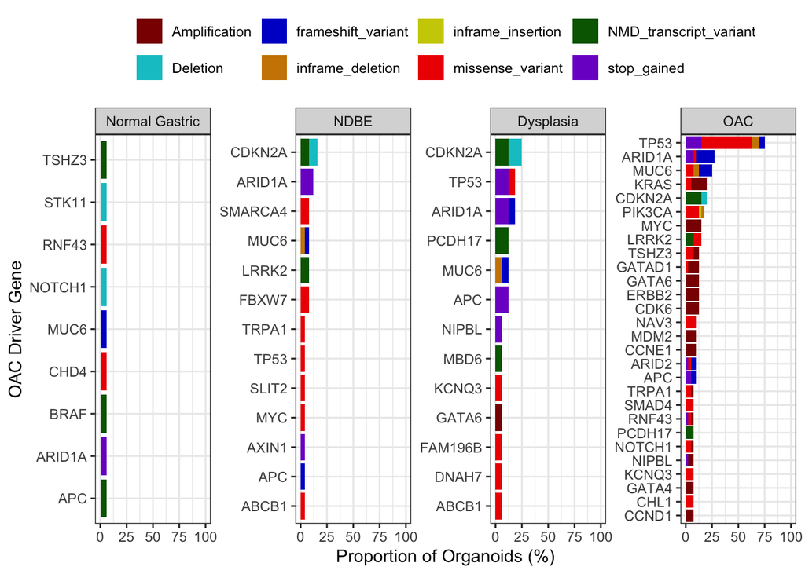

```r
drivers.counts <- merge(x = drivers.counts, y = drivers.total_prop)

drivers.counts %>%
  mutate(Gene = reorder_within(Gene, total_proportion, Group)) %>%
  ggplot(aes(x = proportion, y = Gene, fill = mutationType)) +
  theme_bw() +
  geom_bar(stat = 'identity') +
  theme(legend.position = 'top', legend.title = element_blank()) +
  scale_fill_manual(values = c('darkred','turquoise3','blue3','orange3',
                               'yellow3','red2','darkgreen','purple3')) +
  scale_y_reordered() +
  facet_wrap(~Group, nrow = 1, scales = 'free_y') +
  xlim(c(0,100)) +
  labs(x = 'Proportion of Organoids (%)', y = 'OAC Driver Gene')
```

```r
ggsave(filename = 'Results/FullOrganoids_AlterationSet.pdf', height = 5)
```